# Stage_Jordan_Analyses_ImmunoProfiler

### Tableau-synthèse

#### data_mut_narm

**Dimensions:** 212 x 72  
**Doublons:** 0

Variable

Stats / valeurs

Fréq. (% de valide)

Diagramme

Manquant

num_inclusion  
[character]

1. 01-0486  
2. 01-0584  
3. 01-0597  
4. 01-0926  
5. 01-0952  
6. 01-1036  
7. 01-1051  
8. 01-1064  
9. 01-1068  
10. 01-1071  
[ 202 autres ]

1 ( 0.5%)  
1 ( 0.5%)  
1 ( 0.5%)  
1 ( 0.5%)  
1 ( 0.5%)  
1 ( 0.5%)  
1 ( 0.5%)  
1 ( 0.5%)  
1 ( 0.5%)  
1 ( 0.5%)  
202 (95.3%)

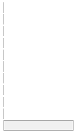

0  
(0.0%)

mut_ABL1  
[numeric]

Min : 0  
Moy : 0  
Max : 1

0 : 211 (99.5%)  
1 : 1 ( 0.5%)

0  
(0.0%)

mut_AKT1  
[numeric]

1 valeur unique

0 : 212 (100.0%)

0  
(0.0%)

mut_AKT2  
[numeric]

Min : 0  
Moy : 0  
Max : 1

0 : 209 (98.6%)  
1 : 3 ( 1.4%)

0  
(0.0%)

mut_ALK  
[numeric]

Min : 0  
Moy : 0  
Max : 1

0 : 209 (98.6%)  
1 : 3 ( 1.4%)

0  
(0.0%)

mut_APC  
[numeric]

Min : 0  
Moy : 0.1  
Max : 1

0 : 189 (89.2%)  
1 : 23 (10.8%)

0  
(0.0%)

mut_AXL  
[numeric]

Min : 0  
Moy : 0  
Max : 1

0 : 210 (99.1%)  
1 : 2 ( 0.9%)

0  
(0.0%)

mut_BRAF  
[numeric]

Min : 0  
Moy : 0  
Max : 1

0 : 209 (98.6%)  
1 : 3 ( 1.4%)

0  
(0.0%)

mut_BRCA1  
[numeric]

Min : 0  
Moy : 0  
Max : 1

0 : 211 (99.5%)  
1 : 1 ( 0.5%)

0  
(0.0%)

mut_BRCA2  
[numeric]

Min : 0  
Moy : 0  
Max : 1

0 : 209 (98.6%)  
1 : 3 ( 1.4%)

0  
(0.0%)

mut_CDKN2A  
[numeric]

1 valeur unique

0 : 212 (100.0%)

0  
(0.0%)

mut_CSF1  
[numeric]

Min : 0  
Moy : 0  
Max : 1

0 : 211 (99.5%)  
1 : 1 ( 0.5%)

0  
(0.0%)

mut_CSF1R  
[numeric]

Min : 0  
Moy : 0  
Max : 1

0 : 211 (99.5%)  
1 : 1 ( 0.5%)

0  
(0.0%)

mut_DDB2  
[numeric]

1 valeur unique

0 : 212 (100.0%)

0  
(0.0%)

mut_DDR1  
[numeric]

Min : 0  
Moy : 0  
Max : 1

0 : 208 (98.1%)  
1 : 4 ( 1.9%)

0  
(0.0%)

mut_DDR2  
[numeric]

Min : 0  
Moy : 0  
Max : 1

0 : 211 (99.5%)  
1 : 1 ( 0.5%)

0  
(0.0%)

mut_EGFR  
[numeric]

Min : 0  
Moy : 0  
Max : 1

0 : 210 (99.1%)  
1 : 2 ( 0.9%)

0  
(0.0%)

mut_ERBB2  
[numeric]

Min : 0  
Moy : 0  
Max : 1

0 : 204 (96.2%)  
1 : 8 ( 3.8%)

0  
(0.0%)

mut_FGFR1  
[numeric]

1 valeur unique

0 : 212 (100.0%)

0  
(0.0%)

mut_FGFR2  
[numeric]

Min : 0  
Moy : 0  
Max : 1

0 : 210 (99.1%)  
1 : 2 ( 0.9%)

0  
(0.0%)

mut_FGFR3  
[numeric]

Min : 0  
Moy : 0  
Max : 1

0 : 211 (99.5%)  
1 : 1 ( 0.5%)

0  
(0.0%)

mut_FGFR4  
[numeric]

Min : 0  
Moy : 0  
Max : 1

0 : 211 (99.5%)  
1 : 1 ( 0.5%)

0  
(0.0%)

mut_FLT1  
[numeric]

Min : 0  
Moy : 0  
Max : 1

0 : 210 (99.1%)  
1 : 2 ( 0.9%)

0  
(0.0%)

mut_FLT3  
[numeric]

Min : 0  
Moy : 0  
Max : 1

0 : 211 (99.5%)  
1 : 1 ( 0.5%)

0  
(0.0%)

mut_FLT4  
[numeric]

Min : 0  
Moy : 0  
Max : 1

0 : 211 (99.5%)  
1 : 1 ( 0.5%)

0  
(0.0%)

mut_GNAQ  
[numeric]

1 valeur unique

0 : 212 (100.0%)

0  
(0.0%)

mut_HRAS  
[numeric]

Min : 0  
Moy : 0  
Max : 1

0 : 211 (99.5%)  
1 : 1 ( 0.5%)

0  
(0.0%)

mut_IGF1R  
[numeric]

Min : 0  
Moy : 0  
Max : 1

0 : 207 (97.6%)  
1 : 5 ( 2.4%)

0  
(0.0%)

mut_JAK2  
[numeric]

Min : 0  
Moy : 0  
Max : 1

0 : 209 (98.6%)  
1 : 3 ( 1.4%)

0  
(0.0%)

mut_JAK3  
[numeric]

Min : 0  
Moy : 0  
Max : 1

0 : 209 (98.6%)  
1 : 3 ( 1.4%)

0  
(0.0%)

mut_KDR  
[numeric]

Min : 0  
Moy : 0  
Max : 1

0 : 205 (96.7%)  
1 : 7 ( 3.3%)

0  
(0.0%)

mut_KIT  
[numeric]

Min : 0  
Moy : 0  
Max : 1

0 : 210 (99.1%)  
1 : 2 ( 0.9%)

0  
(0.0%)

mut_KRAS  
[numeric]

Min : 0  
Moy : 0.2  
Max : 1

0 : 166 (78.3%)  
1 : 46 (21.7%)

0  
(0.0%)

mut_MEN1  
[numeric]

1 valeur unique

0 : 212 (100.0%)

0  
(0.0%)

mut_MERTK  
[numeric]

Min : 0  
Moy : 0  
Max : 1

0 : 210 (99.1%)  
1 : 2 ( 0.9%)

0  
(0.0%)

mut_MET  
[numeric]

Min : 0  
Moy : 0  
Max : 1

0 : 206 (97.2%)  
1 : 6 ( 2.8%)

0  
(0.0%)

mut_MPL  
[numeric]

Min : 0  
Moy : 0  
Max : 1

0 : 211 (99.5%)  
1 : 1 ( 0.5%)

0  
(0.0%)

mut_MST1R  
[numeric]

Min : 0  
Moy : 0  
Max : 1

0 : 208 (98.1%)  
1 : 4 ( 1.9%)

0  
(0.0%)

mut_MTOR  
[numeric]

Min : 0  
Moy : 0  
Max : 1

0 : 210 (99.1%)  
1 : 2 ( 0.9%)

0  
(0.0%)

mut_MUSK  
[numeric]

Min : 0  
Moy : 0  
Max : 1

0 : 211 (99.5%)  
1 : 1 ( 0.5%)

0  
(0.0%)

mut_NRAS  
[numeric]

Min : 0  
Moy : 0  
Max : 1

0 : 210 (99.1%)  
1 : 2 ( 0.9%)

0  
(0.0%)

mut_PDGFA  
[numeric]

1 valeur unique

0 : 212 (100.0%)

0  
(0.0%)

mut_PDGFB  
[numeric]

1 valeur unique

0 : 212 (100.0%)

0  
(0.0%)

mut_PDGFRA  
[numeric]

Min : 0  
Moy : 0  
Max : 1

0 : 211 (99.5%)  
1 : 1 ( 0.5%)

0  
(0.0%)

mut_PDGFRB  
[numeric]

Min : 0  
Moy : 0  
Max : 1

0 : 205 (96.7%)  
1 : 7 ( 3.3%)

0  
(0.0%)

mut_PIK3CA  
[numeric]

Min : 0  
Moy : 0.1  
Max : 1

0 : 194 (91.5%)  
1 : 18 ( 8.5%)

0  
(0.0%)

mut_PIK3R1  
[numeric]

Min : 0  
Moy : 0  
Max : 1

0 : 209 (98.6%)  
1 : 3 ( 1.4%)

0  
(0.0%)

mut_PTCH1  
[numeric]

Min : 0  
Moy : 0  
Max : 1

0 : 209 (98.6%)  
1 : 3 ( 1.4%)

0  
(0.0%)

mut_PTEN  
[numeric]

Min : 0  
Moy : 0  
Max : 1

0 : 211 (99.5%)  
1 : 1 ( 0.5%)

0  
(0.0%)

mut_RAF1  
[numeric]

Min : 0  
Moy : 0  
Max : 1

0 : 210 (99.1%)  
1 : 2 ( 0.9%)

0  
(0.0%)

mut_RB1  
[numeric]

Min : 0  
Moy : 0  
Max : 1

0 : 210 (99.1%)  
1 : 2 ( 0.9%)

0  
(0.0%)

mut_RET  
[numeric]

Min : 0  
Moy : 0  
Max : 1

0 : 209 (98.6%)  
1 : 3 ( 1.4%)

0  
(0.0%)

mut_ROR1  
[numeric]

Min : 0  
Moy : 0  
Max : 1

0 : 210 (99.1%)  
1 : 2 ( 0.9%)

0  
(0.0%)

mut_ROR2  
[numeric]

Min : 0  
Moy : 0  
Max : 1

0 : 211 (99.5%)  
1 : 1 ( 0.5%)

0  
(0.0%)

mut_ROS1  
[numeric]

Min : 0  
Moy : 0  
Max : 1

0 : 206 (97.2%)  
1 : 6 ( 2.8%)

0  
(0.0%)

mut_RYK  
[numeric]

1 valeur unique

0 : 212 (100.0%)

0  
(0.0%)

mut_SDHAF2  
[numeric]

1 valeur unique

0 : 212 (100.0%)

0  
(0.0%)

mut_SDHB  
[numeric]

1 valeur unique

0 : 212 (100.0%)

0  
(0.0%)

mut_SDHC  
[numeric]

1 valeur unique

0 : 212 (100.0%)

0  
(0.0%)

mut_SDHD  
[numeric]

Min : 0  
Moy : 0  
Max : 1

0 : 211 (99.5%)  
1 : 1 ( 0.5%)

0  
(0.0%)

mut_SMARCB1  
[numeric]

Min : 0  
Moy : 0  
Max : 1

0 : 210 (99.1%)  
1 : 2 ( 0.9%)

0  
(0.0%)

mut_SMO  
[numeric]

Min : 0  
Moy : 0  
Max : 1

0 : 210 (99.1%)  
1 : 2 ( 0.9%)

0  
(0.0%)

mut_SRC  
[numeric]

Min : 0  
Moy : 0  
Max : 1

0 : 211 (99.5%)  
1 : 1 ( 0.5%)

0  
(0.0%)

mut_STK11  
[numeric]

Min : 0  
Moy : 0  
Max : 1

0 : 207 (97.6%)  
1 : 5 ( 2.4%)

0  
(0.0%)

mut_TEK  
[numeric]

Min : 0  
Moy : 0  
Max : 1

0 : 209 (98.6%)  
1 : 3 ( 1.4%)

0  
(0.0%)

mut_TIE1  
[numeric]

Min : 0  
Moy : 0  
Max : 1

0 : 211 (99.5%)  
1 : 1 ( 0.5%)

0  
(0.0%)

mut_TP53  
[numeric]

Min : 0  
Moy : 0.4  
Max : 1

0 : 130 (61.3%)  
1 : 82 (38.7%)

0  
(0.0%)

mut_TSC1  
[numeric]

Min : 0  
Moy : 0  
Max : 1

0 : 210 (99.1%)  
1 : 2 ( 0.9%)

0  
(0.0%)

mut_TSC2  
[numeric]

Min : 0  
Moy : 0  
Max : 1

0 : 208 (98.1%)  
1 : 4 ( 1.9%)

0  
(0.0%)

mut_TYRO3  
[numeric]

Min : 0  
Moy : 0  
Max : 1

0 : 211 (99.5%)  
1 : 1 ( 0.5%)

0  
(0.0%)

mut_VHL  
[numeric]

1 valeur unique

0 : 212 (100.0%)

0  
(0.0%)

cat_cancer  
[character]

1. Carcinome colorectal  
2. ORL  
3. Cerveau  
4. Pancréas  
5. autres carcinomes  
6. Ovaire Carcinome  
7. Sarcome  
8. Sein  
9. Utérus  
10. Prostate  
[ 14 autres ]

49 (23.1%)  
30 (14.2%)  
19 ( 9.0%)  
19 ( 9.0%)  
16 ( 7.5%)  
16 ( 7.5%)  
15 ( 7.1%)  
11 ( 5.2%)  
7 ( 3.3%)  
6 ( 2.8%)  
24 (11.3%)

0  
(0.0%)

### Statistiques de mutation par cancer

```r
data_subset <- subset(data_mut_narm, select = -num_inclusion) # Exclure la colonne "num_inclusion" du dataframe sinon c'est prend trop de place

tab <- tableby(
  data_subset$cat_cancer ~ ., # On regarde les stats que pour les colonnes gènes
  data=data_subset)

summary(tab, pfootnote = TRUE)
```

|  | Autres (N=1) | autres carcinomes (N=16) | autres tumeurs (N=3) | Carcinome colorectal (N=49) | Cerveau (N=19) | Estomac (N=3) | HCC (N=1) | intestin (N=1) | Intestin (N=1) | Lymphome (N=1) | Œsophage (N=2) | ORL (N=30) | Ovaire Autres (N=2) | Ovaire Carcinome (N=16) | Pancréas (N=19) | Poumon (N=4) | Prostate (N=6) | RCC (N=1) | Sarcome (N=15) | Sein (N=11) | Testicules (N=1) | Thyroide (N=1) | Utérus (N=7) | Voies urinaires (N=2) | Total (N=212) | p value |
| --- | --- | --- | --- | --- | --- | --- | --- | --- | --- | --- | --- | --- | --- | --- | --- | --- | --- | --- | --- | --- | --- | --- | --- | --- | --- | --- |
| **mut_ABL1** |  |  |  |  |  |  |  |  |  |  |  |  |  |  |  |  |  |  |  |  |  |  |  |  |  | 0.957<sup>1</sup> |
| Mean (SD) | 0.000 (NA) | 0.000 (0.000) | 0.000 (0.000) | 0.000 (0.000) | 0.000 (0.000) | 0.000 (0.000) | 0.000 (NA) | 0.000 (NA) | 0.000 (NA) | 0.000 (NA) | 0.000 (0.000) | 0.000 (0.000) | 0.000 (0.000) | 0.000 (0.000) | 0.000 (0.000) | 0.000 (0.000) | 0.000 (0.000) | 0.000 (NA) | 0.067 (0.258) | 0.000 (0.000) | 0.000 (NA) | 0.000 (NA) | 0.000 (0.000) | 0.000 (0.000) | 0.005 (0.069) |  |
| Range | 0.000 - 0.000 | 0.000 - 0.000 | 0.000 - 0.000 | 0.000 - 0.000 | 0.000 - 0.000 | 0.000 - 0.000 | 0.000 - 0.000 | 0.000 - 0.000 | 0.000 - 0.000 | 0.000 - 0.000 | 0.000 - 0.000 | 0.000 - 0.000 | 0.000 - 0.000 | 0.000 - 0.000 | 0.000 - 0.000 | 0.000 - 0.000 | 0.000 - 0.000 | 0.000 - 0.000 | 0.000 - 1.000 | 0.000 - 0.000 | 0.000 - 0.000 | 0.000 - 0.000 | 0.000 - 0.000 | 0.000 - 0.000 | 0.000 - 1.000 |  |
| **mut_AKT1** |  |  |  |  |  |  |  |  |  |  |  |  |  |  |  |  |  |  |  |  |  |  |  |  |  | NaN<sup>1</sup> |
| Mean (SD) | 0.000 (NA) | 0.000 (0.000) | 0.000 (0.000) | 0.000 (0.000) | 0.000 (0.000) | 0.000 (0.000) | 0.000 (NA) | 0.000 (NA) | 0.000 (NA) | 0.000 (NA) | 0.000 (0.000) | 0.000 (0.000) | 0.000 (0.000) | 0.000 (0.000) | 0.000 (0.000) | 0.000 (0.000) | 0.000 (0.000) | 0.000 (NA) | 0.000 (0.000) | 0.000 (0.000) | 0.000 (NA) | 0.000 (NA) | 0.000 (0.000) | 0.000 (0.000) | 0.000 (0.000) |  |
| Range | 0.000 - 0.000 | 0.000 - 0.000 | 0.000 - 0.000 | 0.000 - 0.000 | 0.000 - 0.000 | 0.000 - 0.000 | 0.000 - 0.000 | 0.000 - 0.000 | 0.000 - 0.000 | 0.000 - 0.000 | 0.000 - 0.000 | 0.000 - 0.000 | 0.000 - 0.000 | 0.000 - 0.000 | 0.000 - 0.000 | 0.000 - 0.000 | 0.000 - 0.000 | 0.000 - 0.000 | 0.000 - 0.000 | 0.000 - 0.000 | 0.000 - 0.000 | 0.000 - 0.000 | 0.000 - 0.000 | 0.000 - 0.000 | 0.000 - 0.000 |  |
| **mut_AKT2** |  |  |  |  |  |  |  |  |  |  |  |  |  |  |  |  |  |  |  |  |  |  |  |  |  | 0.952<sup>1</sup> |
| Mean (SD) | 0.000 (NA) | 0.000 (0.000) | 0.000 (0.000) | 0.020 (0.143) | 0.000 (0.000) | 0.000 (0.000) | 0.000 (NA) | 0.000 (NA) | 0.000 (NA) | 0.000 (NA) | 0.000 (0.000) | 0.000 (0.000) | 0.000 (0.000) | 0.000 (0.000) | 0.000 (0.000) | 0.000 (0.000) | 0.000 (0.000) | 0.000 (NA) | 0.067 (0.258) | 0.000 (0.000) | 0.000 (NA) | 0.000 (NA) | 0.143 (0.378) | 0.000 (0.000) | 0.014 (0.118) |  |
| Range | 0.000 - 0.000 | 0.000 - 0.000 | 0.000 - 0.000 | 0.000 - 1.000 | 0.000 - 0.000 | 0.000 - 0.000 | 0.000 - 0.000 | 0.000 - 0.000 | 0.000 - 0.000 | 0.000 - 0.000 | 0.000 - 0.000 | 0.000 - 0.000 | 0.000 - 0.000 | 0.000 - 0.000 | 0.000 - 0.000 | 0.000 - 0.000 | 0.000 - 0.000 | 0.000 - 0.000 | 0.000 - 1.000 | 0.000 - 0.000 | 0.000 - 0.000 | 0.000 - 0.000 | 0.000 - 1.000 | 0.000 - 0.000 | 0.000 - 1.000 |  |
| **mut_ALK** |  |  |  |  |  |  |  |  |  |  |  |  |  |  |  |  |  |  |  |  |  |  |  |  |  | 0.534<sup>1</sup> |
| Mean (SD) | 0.000 (NA) | 0.000 (0.000) | 0.000 (0.000) | 0.000 (0.000) | 0.000 (0.000) | 0.000 (0.000) | 0.000 (NA) | 0.000 (NA) | 0.000 (NA) | 0.000 (NA) | 0.000 (0.000) | 0.033 (0.183) | 0.000 (0.000) | 0.000 (0.000) | 0.000 (0.000) | 0.250 (0.500) | 0.000 (0.000) | 0.000 (NA) | 0.067 (0.258) | 0.000 (0.000) | 0.000 (NA) | 0.000 (NA) | 0.000 (0.000) | 0.000 (0.000) | 0.014 (0.118) |  |
| Range | 0.000 - 0.000 | 0.000 - 0.000 | 0.000 - 0.000 | 0.000 - 0.000 | 0.000 - 0.000 | 0.000 - 0.000 | 0.000 - 0.000 | 0.000 - 0.000 | 0.000 - 0.000 | 0.000 - 0.000 | 0.000 - 0.000 | 0.000 - 1.000 | 0.000 - 0.000 | 0.000 - 0.000 | 0.000 - 0.000 | 0.000 - 1.000 | 0.000 - 0.000 | 0.000 - 0.000 | 0.000 - 1.000 | 0.000 - 0.000 | 0.000 - 0.000 | 0.000 - 0.000 | 0.000 - 0.000 | 0.000 - 0.000 | 0.000 - 1.000 |  |
| **mut_APC** |  |  |  |  |  |  |  |  |  |  |  |  |  |  |  |  |  |  |  |  |  |  |  |  |  | 0.004<sup>1</sup> |
| Mean (SD) | 0.000 (NA) | 0.000 (0.000) | 0.000 (0.000) | 0.347 (0.481) | 0.053 (0.229) | 0.333 (0.577) | 0.000 (NA) | 0.000 (NA) | 0.000 (NA) | 0.000 (NA) | 0.000 (0.000) | 0.000 (0.000) | 0.000 (0.000) | 0.000 (0.000) | 0.053 (0.229) | 0.000 (0.000) | 0.000 (0.000) | 0.000 (NA) | 0.133 (0.352) | 0.091 (0.302) | 0.000 (NA) | 0.000 (NA) | 0.000 (0.000) | 0.000 (0.000) | 0.108 (0.312) |  |
| Range | 0.000 - 0.000 | 0.000 - 0.000 | 0.000 - 0.000 | 0.000 - 1.000 | 0.000 - 1.000 | 0.000 - 1.000 | 0.000 - 0.000 | 0.000 - 0.000 | 0.000 - 0.000 | 0.000 - 0.000 | 0.000 - 0.000 | 0.000 - 0.000 | 0.000 - 0.000 | 0.000 - 0.000 | 0.000 - 1.000 | 0.000 - 0.000 | 0.000 - 0.000 | 0.000 - 0.000 | 0.000 - 1.000 | 0.000 - 1.000 | 0.000 - 0.000 | 0.000 - 0.000 | 0.000 - 0.000 | 0.000 - 0.000 | 0.000 - 1.000 |  |
| **mut_AXL** |  |  |  |  |  |  |  |  |  |  |  |  |  |  |  |  |  |  |  |  |  |  |  |  |  | 0.998<sup>1</sup> |
| Mean (SD) | 0.000 (NA) | 0.000 (0.000) | 0.000 (0.000) | 0.000 (0.000) | 0.000 (0.000) | 0.000 (0.000) | 0.000 (NA) | 0.000 (NA) | 0.000 (NA) | 0.000 (NA) | 0.000 (0.000) | 0.033 (0.183) | 0.000 (0.000) | 0.000 (0.000) | 0.000 (0.000) | 0.000 (0.000) | 0.000 (0.000) | 0.000 (NA) | 0.067 (0.258) | 0.000 (0.000) | 0.000 (NA) | 0.000 (NA) | 0.000 (0.000) | 0.000 (0.000) | 0.009 (0.097) |  |
| Range | 0.000 - 0.000 | 0.000 - 0.000 | 0.000 - 0.000 | 0.000 - 0.000 | 0.000 - 0.000 | 0.000 - 0.000 | 0.000 - 0.000 | 0.000 - 0.000 | 0.000 - 0.000 | 0.000 - 0.000 | 0.000 - 0.000 | 0.000 - 1.000 | 0.000 - 0.000 | 0.000 - 0.000 | 0.000 - 0.000 | 0.000 - 0.000 | 0.000 - 0.000 | 0.000 - 0.000 | 0.000 - 1.000 | 0.000 - 0.000 | 0.000 - 0.000 | 0.000 - 0.000 | 0.000 - 0.000 | 0.000 - 0.000 | 0.000 - 1.000 |  |
| **mut_BRAF** |  |  |  |  |  |  |  |  |  |  |  |  |  |  |  |  |  |  |  |  |  |  |  |  |  | 1.000<sup>1</sup> |
| Mean (SD) | 0.000 (NA) | 0.000 (0.000) | 0.000 (0.000) | 0.041 (0.200) | 0.053 (0.229) | 0.000 (0.000) | 0.000 (NA) | 0.000 (NA) | 0.000 (NA) | 0.000 (NA) | 0.000 (0.000) | 0.000 (0.000) | 0.000 (0.000) | 0.000 (0.000) | 0.000 (0.000) | 0.000 (0.000) | 0.000 (0.000) | 0.000 (NA) | 0.000 (0.000) | 0.000 (0.000) | 0.000 (NA) | 0.000 (NA) | 0.000 (0.000) | 0.000 (0.000) | 0.014 (0.118) |  |
| Range | 0.000 - 0.000 | 0.000 - 0.000 | 0.000 - 0.000 | 0.000 - 1.000 | 0.000 - 1.000 | 0.000 - 0.000 | 0.000 - 0.000 | 0.000 - 0.000 | 0.000 - 0.000 | 0.000 - 0.000 | 0.000 - 0.000 | 0.000 - 0.000 | 0.000 - 0.000 | 0.000 - 0.000 | 0.000 - 0.000 | 0.000 - 0.000 | 0.000 - 0.000 | 0.000 - 0.000 | 0.000 - 0.000 | 0.000 - 0.000 | 0.000 - 0.000 | 0.000 - 0.000 | 0.000 - 0.000 | 0.000 - 0.000 | 0.000 - 1.000 |  |
| **mut_BRCA1** |  |  |  |  |  |  |  |  |  |  |  |  |  |  |  |  |  |  |  |  |  |  |  |  |  | 0.973<sup>1</sup> |
| Mean (SD) | 0.000 (NA) | 0.000 (0.000) | 0.000 (0.000) | 0.000 (0.000) | 0.000 (0.000) | 0.000 (0.000) | 0.000 (NA) | 0.000 (NA) | 0.000 (NA) | 0.000 (NA) | 0.000 (0.000) | 0.000 (0.000) | 0.000 (0.000) | 0.062 (0.250) | 0.000 (0.000) | 0.000 (0.000) | 0.000 (0.000) | 0.000 (NA) | 0.000 (0.000) | 0.000 (0.000) | 0.000 (NA) | 0.000 (NA) | 0.000 (0.000) | 0.000 (0.000) | 0.005 (0.069) |  |
| Range | 0.000 - 0.000 | 0.000 - 0.000 | 0.000 - 0.000 | 0.000 - 0.000 | 0.000 - 0.000 | 0.000 - 0.000 | 0.000 - 0.000 | 0.000 - 0.000 | 0.000 - 0.000 | 0.000 - 0.000 | 0.000 - 0.000 | 0.000 - 0.000 | 0.000 - 0.000 | 0.000 - 1.000 | 0.000 - 0.000 | 0.000 - 0.000 | 0.000 - 0.000 | 0.000 - 0.000 | 0.000 - 0.000 | 0.000 - 0.000 | 0.000 - 0.000 | 0.000 - 0.000 | 0.000 - 0.000 | 0.000 - 0.000 | 0.000 - 1.000 |  |
| **mut_BRCA2** |  |  |  |  |  |  |  |  |  |  |  |  |  |  |  |  |  |  |  |  |  |  |  |  |  | 0.770<sup>1</sup> |
| Mean (SD) | 0.000 (NA) | 0.062 (0.250) | 0.000 (0.000) | 0.000 (0.000) | 0.000 (0.000) | 0.000 (0.000) | 0.000 (NA) | 0.000 (NA) | 0.000 (NA) | 0.000 (NA) | 0.000 (0.000) | 0.000 (0.000) | 0.000 (0.000) | 0.000 (0.000) | 0.000 (0.000) | 0.000 (0.000) | 0.167 (0.408) | 0.000 (NA) | 0.067 (0.258) | 0.000 (0.000) | 0.000 (NA) | 0.000 (NA) | 0.000 (0.000) | 0.000 (0.000) | 0.014 (0.118) |  |
| Range | 0.000 - 0.000 | 0.000 - 1.000 | 0.000 - 0.000 | 0.000 - 0.000 | 0.000 - 0.000 | 0.000 - 0.000 | 0.000 - 0.000 | 0.000 - 0.000 | 0.000 - 0.000 | 0.000 - 0.000 | 0.000 - 0.000 | 0.000 - 0.000 | 0.000 - 0.000 | 0.000 - 0.000 | 0.000 - 0.000 | 0.000 - 0.000 | 0.000 - 1.000 | 0.000 - 0.000 | 0.000 - 1.000 | 0.000 - 0.000 | 0.000 - 0.000 | 0.000 - 0.000 | 0.000 - 0.000 | 0.000 - 0.000 | 0.000 - 1.000 |  |
| **mut_CDKN2A** |  |  |  |  |  |  |  |  |  |  |  |  |  |  |  |  |  |  |  |  |  |  |  |  |  | NaN<sup>1</sup> |
| Mean (SD) | 0.000 (NA) | 0.000 (0.000) | 0.000 (0.000) | 0.000 (0.000) | 0.000 (0.000) | 0.000 (0.000) | 0.000 (NA) | 0.000 (NA) | 0.000 (NA) | 0.000 (NA) | 0.000 (0.000) | 0.000 (0.000) | 0.000 (0.000) | 0.000 (0.000) | 0.000 (0.000) | 0.000 (0.000) | 0.000 (0.000) | 0.000 (NA) | 0.000 (0.000) | 0.000 (0.000) | 0.000 (NA) | 0.000 (NA) | 0.000 (0.000) | 0.000 (0.000) | 0.000 (0.000) |  |
| Range | 0.000 - 0.000 | 0.000 - 0.000 | 0.000 - 0.000 | 0.000 - 0.000 | 0.000 - 0.000 | 0.000 - 0.000 | 0.000 - 0.000 | 0.000 - 0.000 | 0.000 - 0.000 | 0.000 - 0.000 | 0.000 - 0.000 | 0.000 - 0.000 | 0.000 - 0.000 | 0.000 - 0.000 | 0.000 - 0.000 | 0.000 - 0.000 | 0.000 - 0.000 | 0.000 - 0.000 | 0.000 - 0.000 | 0.000 - 0.000 | 0.000 - 0.000 | 0.000 - 0.000 | 0.000 - 0.000 | 0.000 - 0.000 | 0.000 - 0.000 |  |

[output cut: 180 more lines]

1. Linear Model ANOVA

### Watterfall Plot pour tous les cancers

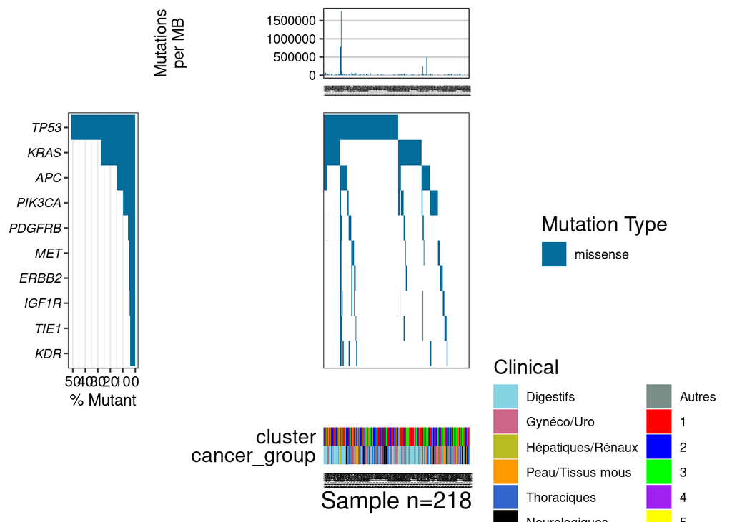

```r
################################################################################
# https://www.cbioportal.org/oncoprinter                                       #
# https://currentprotocols.onlinelibrary.wiley.com/doi/full/10.1002/cpz1.252   #
################################################################################

myVars <-
  d_info_mutation %>%
  mutate(trv_type = "missense") %>%
  select(c("num_inclusion", "gene_symbol", "trv_type", "amino_acid_change")) %>%
  setnames(c("sample", "gene", "mutation", "amino_acid_change"))

myHierarchy <-
  data.table("mutation"=c("missense"), color=c("#046C9A")) # Permet de représenter en priorité des types de mutation, ici on a que des mutations Missense donc pas très utile

mutationBurden <- d_info_mutation[c("num_inclusion", "coverage")] %>% setnames(c("sample", "coverage"))
myMutBurden <- as.numeric(mutationBurden$coverage)
names(myMutBurden) <- mutationBurden$sample

d_cyto_narm <- read.table("cluster_immuno", h = T)



clinicalData <- Clinical(inputData =
                           d_info_mutation %>%
                           select(c("num_inclusion", "cat_cancer")) %>%
                           setnames(c("sample", "Categorie_cancer")) %>%
                           mutate(cancer_group = case_when(Categorie_cancer %in% c("Carcinome colorectal", "Digestif", "Estomac", "intestin", "Intestin", "Œsophage", "Pancréas") ~ "Digestifs",
                                                           Categorie_cancer %in% c("Ovaire Autres", "Ovaire Carcinome", "Prostate", "Testicules", "Thyroide", "Utérus", "Voies urinaires") ~ "Gynéco/Uro",
                                                           Categorie_cancer %in% c("HCC", "RCC") ~ "Hépatiques/Rénaux",
                                                           Categorie_cancer %in% c("Melanome", "sarcome", "Sarcome") ~ "Peau/Tissus mous",
                                                           Categorie_cancer %in% c("Poumon", "ORL") ~ "Thoraciques",
                                                           Categorie_cancer %in% c("Cerveau", "Neuroblastome") ~ "Neurologiques",
                                                           TRUE ~ "Autres")) %>%
                           select(c("sample", "cancer_group")) %>%
                           left_join(d_cyto_narm[c("num_inclusion", "typo")] %>% setnames(c("sample", "cluster")),
                                     d_typo,
                                     by = "sample"),

                         palette = c("Digestifs" = "#85D4E3",  # Couleur représentative pour les cancers digestifs
                                     "Gynéco/Uro" = "#CC6688",  # Couleur rose pour représenter les cancers gynéco-urologiques
                                     "Hépatiques/Rénaux" = "#BBBB22",  # Couleur jaune pour les cancers du foie et des reins
                                     "Peau/Tissus mous" = "#FF9900",  # Couleur orange pour la peau et sarcomes
                                     "Thoraciques" = "#3366CC",  # Bleu pour les cancers thoraciques
                                     "Neurologiques" = "#000000",  # Noir pour les cancers neurologiques
                                     "Autres" = "#798E87",  # Gris pour les autres types de cancers moins communs
                                     "1" = "red",
                                     "2" = "blue",
                                     "3" = "green",
                                     "4" = "purple",
                                     "5" = "yellow"),

                         clinicalLayers = list(theme(axis.text.x = element_text(angle=90, color="black", size=3))),

                         legendColumns = 2)



plotData <- Waterfall(input = myVars,
                      coverage = myMutBurden,
                      mutationHierarchy = myHierarchy,
                      clinical = clinicalData,
                      geneMax = 10,
                      plotA = "burden",
                      plotATally = "complex",
                      plotBTally = "complex",
                      sampleNames = TRUE,
                      sectionHeights = c(0.2, 0.6, 0.2),
                      sectionWidths = c(0.2, 0.8),
                      plotALayers = list(theme(axis.text.x=element_text(angle=90, color="black", size=2))),
                      plotBLayers = list(theme(axis.text.x=element_text(angle=0, color="black", size=10))),
                      plotCLayers = list(theme(axis.text.x=element_text(angle=90, color="black", size=2))))


drawPlot(plotData)
```

```r
# plotData <- Waterfall(myVars, mutationHierarchy = myHierarchy)
# plotData <- Waterfall(myVars, mutationHierarchy = myHierarchy, clinical = clinicalData)
# plotData <- Waterfall(myVars, mutationHierarchy = myHierarchy, coverage=myMutBurden, plotA = "burden")
# plotData <- Waterfall(myVars, labelColumn="amino acid change", mutationHierarchy = myHierarchy, plotATally = "complex", plotBTally = "complex", geneMax=10)

# pdf(file="Figure_1.pdf", height=8, width=12)
# dev.off()

# table(myClinical$Categorie_cancer)
#
# myClinicalColors <- c(
#   "Autres" = "#798E87",
#   "autres carcinomes" = "#C27D38",
#   "autres tumeurs" = "#CCC591",
#   "Carcinome colorectal" = "#29211F",
#   "Cerveau" = "#9C964A",
#   "Digestif" = "#85D4E3",
#   "Estomac" = "#A8B6BF",
#   "HCC" = "#FF0000",
#   "inconnu" = "#00A08A",
#   "intestin" = "#F2AD00",
#   "Intestin" = "#5BBCD6",
#   "Lymphome" = "#046C9A",
#   "Melanome" = "#D69C4E",
#   "Neuroblastome" = "#000000",
#   "Œsophage" = "#446455",
#   "ORL" = "#76AB7F",
#   "Ovaire Autres" = "#674172",
#   "Ovaire Carcinome" = "#CC6688",
#   "Pancréas" = "#BA7FAD",
#   "Poumon" = "#3366CC",
#   "Prostate" = "#88AA77",
#   "RCC" = "#BBBB22",
#   "sarcome" = "#FF9900",
#   "Sarcome" = "#DD4477",
#   "Sein" = "#994499",
#   "Testicules" = "#22AA99",
#   "Thyroide" = "#AAAA11",
#   "Utérus" = "#6633CC",
#   "Voies urinaires" = "#E67300"
# )
```

D’un point de vue pancancer, le gène TP53 est celui retrouvé muté dans la majorité des cancers

### Watterfall Plot pour Cancer colorectal

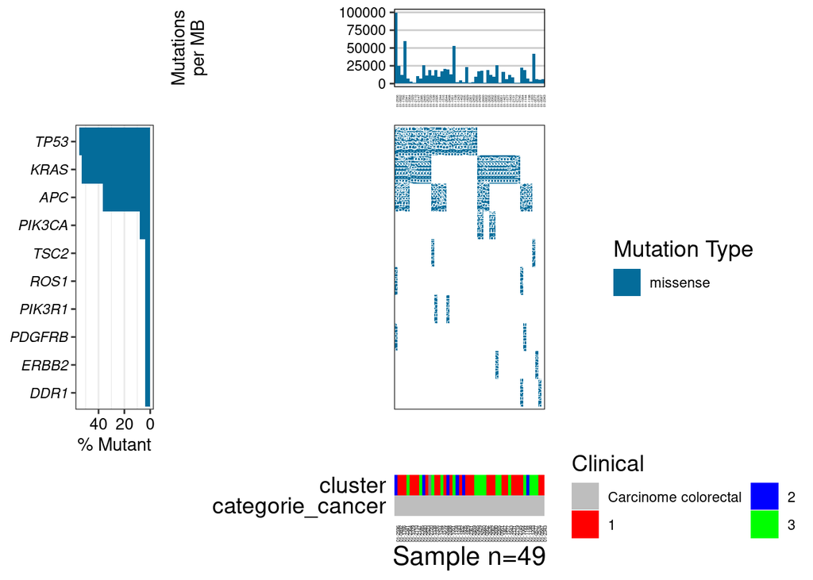

```r
myVars2 <-
  d_info_mutation %>%
  filter(cat_cancer == "Carcinome colorectal") %>%
  mutate(trv_type = "missense") %>%
  select(c("num_inclusion", "gene_symbol", "trv_type", "amino_acid_change")) %>%
  setnames(c("sample", "gene", "mutation", "amino_acid_change"))

clinicalData <- Clinical(inputData =
                           d_info_mutation %>%
                           filter(cat_cancer == "Carcinome colorectal") %>%
                           select(c("num_inclusion", "cat_cancer")) %>%
                           setnames(c("sample", "Categorie_cancer")) %>%
                           left_join(d_cyto_narm[c("num_inclusion", "typo")] %>% setnames(c("sample", "cluster")),
                                     d_typo,
                                     by = "sample"),

                         palette = c("Carcinome colorectal" = "grey",
                                     "1" = "red",
                                     "2" = "blue",
                                     "3" = "green",
                                     "4" = "purple",
                                     "5" = "yellow"),

                         clinicalLayers = list(theme(axis.text.x = element_text(angle=90, color="black", size=3))),

                         legendColumns = 2)


plotData <- Waterfall(input = myVars2,
                      coverage = myMutBurden,
                      mutationHierarchy = myHierarchy,
                      clinical = clinicalData,
                      geneMax = 10,
                      plotA = "burden",
                      plotATally = "complex",
                      plotBTally = "complex",
                      sampleNames = TRUE,
                      sectionHeights = c(0.2, 0.6, 0.2),
                      sectionWidths = c(0.2, 0.8),
                      plotALayers = list(theme(axis.text.x=element_text(angle=90, color="black", size=2))),
                      plotBLayers = list(theme(axis.text.x=element_text(angle=0, color="black", size=10))),
                      plotCLayers = list(theme(axis.text.x=element_text(angle=90, color="black", size=2))),
                      labelColumn="amino_acid_change",
                      labelSize = 1.7,
                      labelAngle = 90)

drawPlot(plotData)
```

D’un point de vue cancer colorectal, les gènes KRAS et APC sont mutés dans la majorité des cancers colorectaux (50% des patients pour KRAS et 35% pour APC) En prenant en compte le gène TP53 muté avec sa dimension pancancer : Dans cette cohorte, le profil mutationnel d’un patient atteint de cancer colorectal est : TP53 muté / KRAS muté / APC muté

### Watterfall Plot pour Cancer ORL

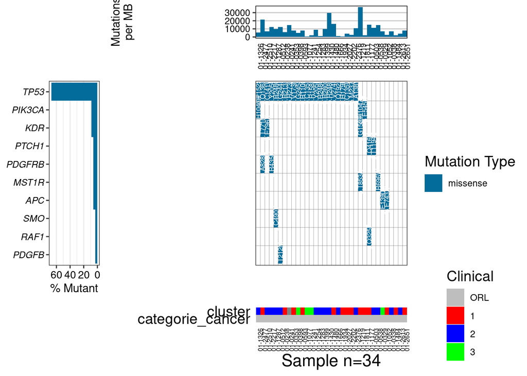

```r
myVars3 <- d_info_mutation %>% filter(d_info_mutation$cat_cancer == "ORL")
myVars3$trv_type <- "missense"

myVars3 <- myVars3[c("num_inclusion", "gene_symbol", "trv_type", "amino_acid_change")]
setnames(myVars3, c("sample", "gene", "mutation", "amino_acid_change"))

myHierarchy3 <- data.table("mutation"=c("missense"), color=c("#046C9A")) # Permet de représenter en priorité des types de mutation, ici on a que des mutations Missense donc pas très utile

myClinical <- d_info_mutation %>% filter(d_info_mutation$cat_cancer == "ORL")
myClinical <- myClinical[c("num_inclusion", "cat_cancer")]
setnames(myClinical, c("sample", "Categorie_cancer"))

d_typo <- d_cyto_narm[c("num_inclusion", "typo")] %>% setnames(c("sample", "cluster"))
myClinical <- left_join(myClinical, d_typo, by = "sample")

myClinicalColors <- c(
  "ORL" = "grey",
  "1" = "red",
  "2" = "blue",
  "3" = "green",
  "4" = "purple",
  "5" = "yellow"
)

myHierarchy2 <- data.table("mutation"=c("missense"), color=c("#046C9A")) # Permet de représenter en priorité des types de mutation, ici on a que des mutations Missense donc pas très utile

LayerClinic <- list(theme(axis.text.x=element_text(angle=90, color="black", size= 6)))

clinicalData <- Clinical(inputData = myClinical, palette = myClinicalColors, legendColumns = 1, clinicalLayers = LayerClinic)

mutationBurden3 <- d_info_mutation[c("num_inclusion", "coverage")]
setnames(mutationBurden3, c("sample", "coverage"))
myMutBurden3 <- as.numeric(mutationBurden3$coverage)
names(myMutBurden3) <- mutationBurden3$sample

newLayerA <- list(theme(axis.text.x=element_text(angle=90, color="black", size=7)))
newLayerB <- list(theme(axis.text.x=element_text(angle=0, color="black", size=10)))
newLayerC <- list(theme(axis.text.x=element_text(angle=90, color="black", size=7)))

plotData3 <- Waterfall(myVars3, coverage = myMutBurden3, clinical = clinicalData, mutationHierarchy = myHierarchy3, geneMax=10, plotA = "burden", plotATally = "complex",plotALayers = newLayerA, plotBTally = "complex", plotBLayers = newLayerB, sampleNames = TRUE, sectionHeights = c(0.2, 0.6, 0.2), sectionWidths = c(0.2, 0.8), plotCLayers = newLayerC, gridOverlay = TRUE, labelColumn="amino_acid_change", labelSize = 2.25, labelAngle = 90)

drawPlot(plotData3)
```

D’un point de vue cancer ORL, il est dificile de trouver des gènes mutés spécifiques à ce type de cancer. On observe le gène TP53 muté avec sa dimension pancancer. Il est difficile d’établir un profil muationnel pour ce type de cancer

### Watterfall Plot pour Cancer Cerveau

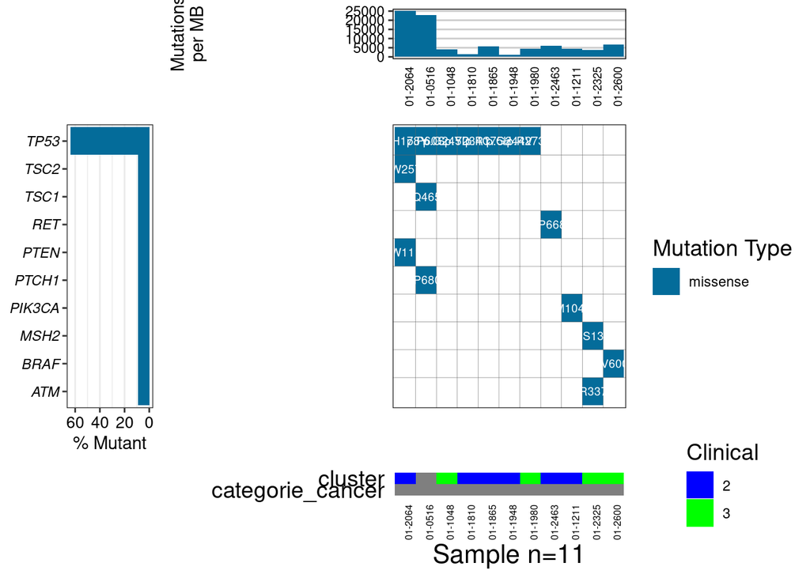

```r
myVars4 <- d_info_mutation %>% filter(d_info_mutation$cat_cancer == "Cerveau")
myVars4$trv_type <- "missense"

myVars4 <- myVars4[c("num_inclusion", "gene_symbol", "trv_type", "amino_acid_change")]
setnames(myVars4, c("sample", "gene", "mutation", "amino_acid_change"))

myHierarchy4 <- data.table("mutation"=c("missense"), color=c("#046C9A")) # Permet de représenter en priorité des types de mutation, ici on a que des mutations Missense donc pas très utile



myClinical <- d_info_mutation %>% filter(d_info_mutation$cat_cancer == "Cerveau")
myClinical <- myClinical[c("num_inclusion", "cat_cancer")]
setnames(myClinical, c("sample", "Categorie_cancer"))

d_typo <- d_cyto_narm[c("num_inclusion", "typo")] %>% setnames(c("sample", "cluster"))
myClinical <- left_join(myClinical, d_typo, by = "sample")



myClinicalColors <- c(
  "ORL" = "grey",
  "1" = "red",
  "2" = "blue",
  "3" = "green",
  "4" = "purple",
  "5" = "yellow"
)

myHierarchy2 <- data.table("mutation"=c("missense"), color=c("#046C9A")) # Permet de représenter en priorité des types de mutation, ici on a que des mutations Missense donc pas très utile


LayerClinic <- list(theme(axis.text.x=element_text(angle=90, color="black", size= 6)))

clinicalData <- Clinical(inputData = myClinical, palette = myClinicalColors, legendColumns = 1, clinicalLayers = LayerClinic)


mutationBurden4 <- d_info_mutation[c("num_inclusion", "coverage")]
setnames(mutationBurden4, c("sample", "coverage"))
myMutBurden4 <- as.numeric(mutationBurden4$coverage)
names(myMutBurden4) <- mutationBurden4$sample

newLayerA <- list(theme(axis.text.x=element_text(angle=90, color="black", size=7)))
newLayerB <- list(theme(axis.text.x=element_text(angle=0, color="black", size=10)))
newLayerC <- list(theme(axis.text.x=element_text(angle=90, color="black", size=7)))

plotData4 <- Waterfall(myVars4, coverage = myMutBurden4, clinical = clinicalData, mutationHierarchy = myHierarchy4, geneMax=10, plotA = "burden", plotATally = "complex",plotALayers = newLayerA, plotBTally = "complex", plotBLayers = newLayerB, sampleNames = TRUE, sectionHeights = c(0.2, 0.6, 0.2), sectionWidths = c(0.2, 0.8), plotCLayers = newLayerC, gridOverlay = TRUE, labelColumn="amino_acid_change", labelSize = 2.5)

drawPlot(plotData4)
```

D’un point de vue cancer du cerveau, il est là aussi dificile de trouver des gènes mutés spécifiques à ce type de cancer. On observe le gène TP53 muté avec sa dimension pancancer. Il est difficile d’établir un profil muationnel pour ce type de cancer

## CNV

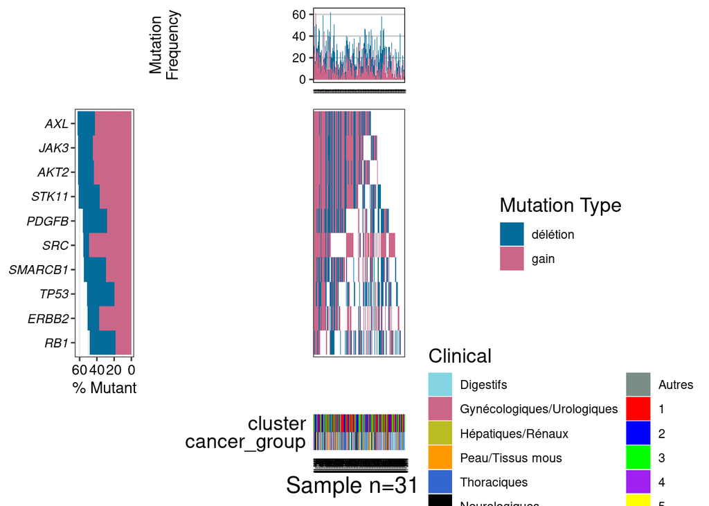

```r
### Waterfall Plot que CSV (all cancers)

myVars5 <- d_info_cnv

setnames(myVars5, c("sample", "gene", "mutation", "Categorie_cancer", "Organ"))

myHierarchy5 <- data.table("mutation"=c("délétion", "gain"), color=c("#046C9A", "#CC6688"))

myClinical <- d_info_cnv
myClinical <- myClinical[c("sample", "Categorie_cancer")]
setnames(myClinical, c("sample", "Categorie_cancer"))

myClinical <- myClinical %>%
  mutate(
    cancer_group = case_when(
      Categorie_cancer %in% c("Carcinome colorectal", "Digestif", "Estomac", "intestin", "Intestin", "Œsophage", "Pancréas") ~ "Digestifs",
      Categorie_cancer %in% c("Ovaire Autres", "Ovaire Carcinome", "Prostate", "Testicules", "Thyroide", "Utérus", "Voies urinaires") ~ "Gynécologiques/Urologiques",
      Categorie_cancer %in% c("HCC", "RCC") ~ "Hépatiques/Rénaux",
      Categorie_cancer %in% c("Melanome", "sarcome", "Sarcome") ~ "Peau/Tissus mous",
      Categorie_cancer %in% c("Poumon", "ORL") ~ "Thoraciques",
      Categorie_cancer %in% c("Cerveau", "Neuroblastome") ~ "Neurologiques",
      TRUE ~ "Autres"
    )
  )

myClinical <- myClinical[,c("sample", "cancer_group")]

d_typo <- d_cyto_narm[c("num_inclusion", "typo")] %>% setnames(c("sample", "cluster"))
myClinical <- left_join(myClinical, d_typo, by = "sample")



myClinicalColors <- c(
  "Digestifs" = "#85D4E3",  # Couleur représentative pour les cancers digestifs
  "Gynécologiques/Urologiques" = "#CC6688",  # Couleur rose pour représenter les cancers gynéco-urologiques
  "Hépatiques/Rénaux" = "#BBBB22",  # Couleur jaune pour les cancers du foie et des reins
  "Peau/Tissus mous" = "#FF9900",  # Couleur orange pour la peau et sarcomes
  "Thoraciques" = "#3366CC",  # Bleu pour les cancers thoraciques
  "Neurologiques" = "#000000",  # Noir pour les cancers neurologiques
  "Autres" = "#798E87",  # Gris pour les autres types de cancers moins communs
  "1" = "red",
  "2" = "blue",
  "3" = "green",
  "4" = "purple",
  "5" = "yellow"
)

LayerClinic <- list(theme(axis.text.x=element_text(angle=90, color="black", size=3)))

clinicalData <- Clinical(inputData = myClinical, palette = myClinicalColors, legendColumns = 2, clinicalLayers = LayerClinic)

newLayerA <- list(theme(axis.text.x=element_text(angle=90, color="black", size=1)))
newLayerB <- list(theme(axis.text.x=element_text(angle=0, color="black", size=10)))
newLayerC <- list(theme(axis.text.x=element_text(angle=90, color="black", size=1)))

plotData5 <- Waterfall(myVars5, mutationHierarchy = myHierarchy5, clinical = clinicalData, geneMax=10, plotATally = "complex", plotALayers = newLayerA, plotBTally = "complex", plotBLayers = newLayerB, sampleNames = TRUE, sectionHeights = c(0.2, 0.6, 0.2), sectionWidths = c(0.2, 0.8), plotCLayers = newLayerC)

drawPlot(plotData5)
```

### Waterfall Plot que CNV pour colorectal cancer

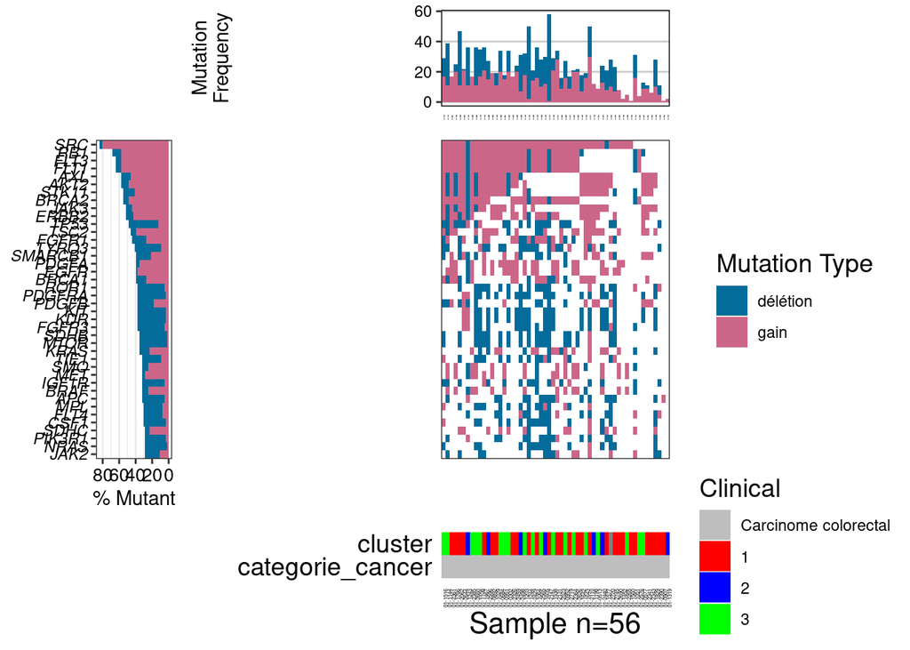

```r
myVars6 <- d_info_cnv %>% filter(Categorie_cancer == "Carcinome colorectal")
myVars6 <- myVars6[,1:3]
setnames(myVars6, c("sample", "gene", "mutation"))

myHierarchy6 <- data.table("mutation"=c("délétion", "gain"), color=c("#046C9A", "#CC6688"))


myClinical <- d_info_cnv %>% filter(Categorie_cancer == "Carcinome colorectal")
myClinical <- myClinical[c("sample", "Categorie_cancer")]

d_typo <- d_cyto_narm[c("num_inclusion", "typo")] %>% setnames(c("sample", "cluster"))
myClinical <- left_join(myClinical, d_typo, by = "sample")



myClinicalColors <- c(
  "Carcinome colorectal" = "grey",
  "1" = "red",
  "2" = "blue",
  "3" = "green",
  "4" = "purple",
  "5" = "yellow"
)


LayerClinic <- list(theme(axis.text.x=element_text(angle=90, color="black", size=3)))

clinicalData <- Clinical(inputData = myClinical, palette = myClinicalColors, legendColumns = 1, clinicalLayers = LayerClinic)


newLayerA <- list(theme(axis.text.x=element_text(angle=90, color="black", size=1)))
newLayerB <- list(theme(axis.text.x=element_text(angle=0, color="black", size=10)))
newLayerC <- list(theme(axis.text.x=element_text(angle=90, color="black", size=1)))

plotData6 <- Waterfall(myVars6, mutationHierarchy = myHierarchy6, clinical = clinicalData, geneMax=40, plotATally = "complex", plotALayers = newLayerA, plotBTally = "complex", plotBLayers = newLayerB, sampleNames = TRUE, sectionHeights = c(0.2, 0.6, 0.2), sectionWidths = c(0.2, 0.8), plotCLayers = newLayerC)

drawPlot(plotData6)
```

### Waterfall Plot que CNV pour cancer ORL

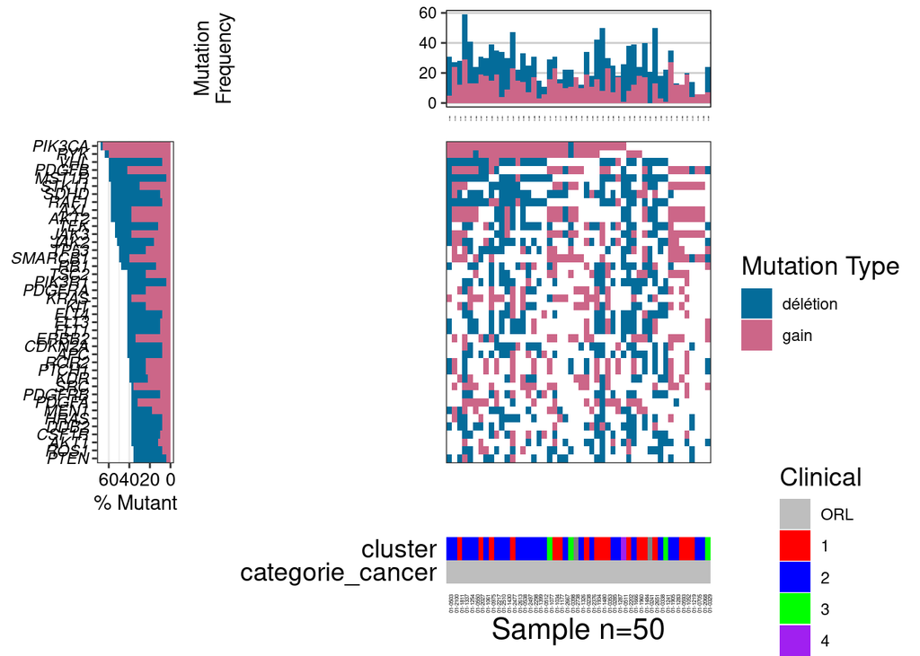

```r
myVars7 <- d_info_cnv %>% filter(Categorie_cancer == "ORL")
myVars7 <- myVars7[,1:3]
setnames(myVars7, c("sample", "gene", "mutation"))

myHierarchy7 <- data.table("mutation"=c("délétion", "gain"), color=c("#046C9A", "#CC6688"))

myClinical <- d_info_cnv %>% filter(Categorie_cancer == "ORL")
myClinical <- myClinical[c("sample", "Categorie_cancer")]

d_typo <- d_cyto_narm[c("num_inclusion", "typo")] %>% setnames(c("sample", "cluster"))
myClinical <- left_join(myClinical, d_typo, by = "sample")



myClinicalColors <- c(
  "ORL" = "grey",
  "1" = "red",
  "2" = "blue",
  "3" = "green",
  "4" = "purple",
  "5" = "yellow"
)


LayerClinic <- list(theme(axis.text.x=element_text(angle=90, color="black", size=3)))

clinicalData <- Clinical(inputData = myClinical, palette = myClinicalColors, legendColumns = 1, clinicalLayers = LayerClinic)


newLayerA <- list(theme(axis.text.x=element_text(angle=90, color="black", size=1)))
newLayerB <- list(theme(axis.text.x=element_text(angle=0, color="black", size=10)))
newLayerC <- list(theme(axis.text.x=element_text(angle=90, color="black", size=1)))

plotData7 <- Waterfall(myVars7, mutationHierarchy = myHierarchy7, clinical = clinicalData, geneMax=40, plotATally = "complex", plotALayers = newLayerA, plotBTally = "complex", plotBLayers = newLayerB, sampleNames = TRUE, sectionHeights = c(0.2, 0.6, 0.2), sectionWidths = c(0.2, 0.8), plotCLayers = newLayerC)

drawPlot(plotData7)
```

## Waterfall Plot CNV + SNV

### Waterfall Plot CNV + SNV (all cancers)

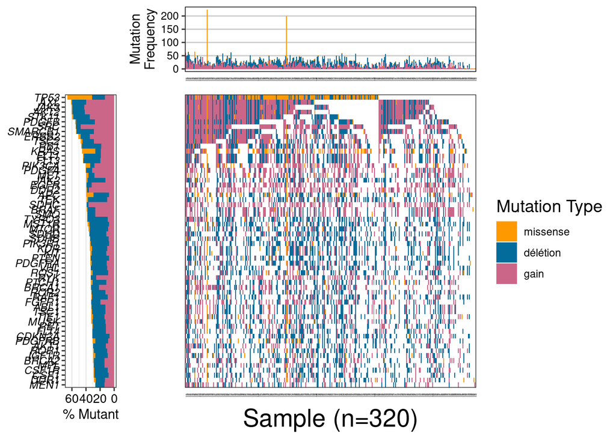

```r
myVars_bis <- myVars[,1:3]
myVars5 <- myVars5[,1:3]
myVars8 <- rbind(myVars_bis, myVars5)

myHierarchy8 <- data.table("mutation"=c("missense", "délétion", "gain"), color=c("#FF9900", "#046C9A", "#CC6688")) # Permet de représenter en priorité des types de mutation, ici on a que des mutations Missense donc pas très utile


newLayerA <- list(theme(axis.text.x=element_text(angle=90, color="black", size=1)))
newLayerB <- list(theme(axis.text.x=element_text(angle=0, color="black", size=10)))
newLayerC <- list(theme(axis.text.x=element_text(angle=90, color="black", size=1)))

plotData8 <- Waterfall(myVars8, mutationHierarchy = myHierarchy8, geneMax=60, plotATally = "complex",plotALayers = newLayerA, plotBTally = "complex", plotBLayers = newLayerB, sampleNames = TRUE, sectionHeights = c(0.2, 0.6, 0.2), sectionWidths = c(0.2, 0.8), plotCLayers = newLayerC)

drawPlot(plotData8)
```

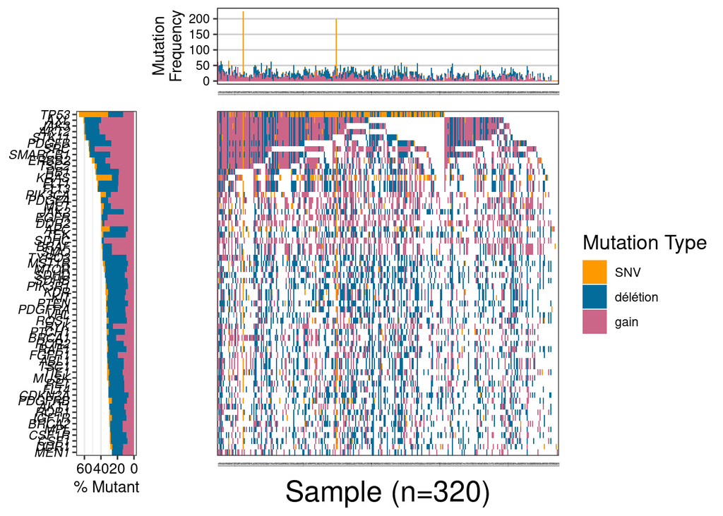

```r
myVars_SNV_allcancer <-
  d_info_mutation %>%
  mutate(trv_type = "SNV") %>%
  select(c("num_inclusion", "gene_symbol", "trv_type")) %>%
  setnames(c("sample", "gene", "mutation"))
myVars_CNV_allcancer <-
  d_info_cnv[,1:3] %>%
  setnames(c("sample", "gene", "mutation"))

myVars_SNV_CNV_allcancer <- rbind(myVars_SNV_allcancer, myVars_CNV_allcancer)

myHierarchy8 <- data.table("mutation"=c("SNV", "délétion", "gain"), color=c("#FF9900", "#046C9A", "#CC6688"))


newLayerA <- list(theme(axis.text.x=element_text(angle=90, color="black", size=1)))
newLayerB <- list(theme(axis.text.x=element_text(angle=0, color="black", size=10)))
newLayerC <- list(theme(axis.text.x=element_text(angle=90, color="black", size=1)))

plotData8 <- Waterfall(myVars_SNV_CNV_allcancer, mutationHierarchy = myHierarchy8, geneMax=60, plotATally = "complex",plotALayers = newLayerA, plotBTally = "complex", plotBLayers = newLayerB, sampleNames = TRUE, sectionHeights = c(0.2, 0.6, 0.2), sectionWidths = c(0.2, 0.8), plotCLayers = newLayerC)

drawPlot(plotData8)
```

```r
dd4_organ <- dd4 %>% select(num_inclusion, organ)

CNV_all_patients <-
  read.delim(file = "projet_ImmunoProfiler_genomique/projet_ImmunoProfiler_genomique/resultats_CNV_all_patients.txt") %>%
  mutate(num_inclusion = substring(num_inclusion, first = 2)) %>% # Je conserve les char après la position 2 (après le "p")
  left_join(dd4_organ, by = "num_inclusion") %>%
  filter(!is.na(organ))

length(unique(CNV_all_patients$num_inclusion))
```

```
## [1] 335
```

```r
SNV_all_patients <-
  read.delim(file = "projet_ImmunoProfiler_genomique/projet_ImmunoProfiler_genomique/resultats_SNV_all_patients.txt") %>%
  mutate(num_inclusion = substring(num_inclusion, first = 2)) %>% # Je conserve les char après la position 2 (après le "p")
  left_join(dd4_organ, by = "num_inclusion") %>%
  filter(!is.na(organ))

length(unique(SNV_all_patients$num_inclusion))
```

```
## [1] 379
```

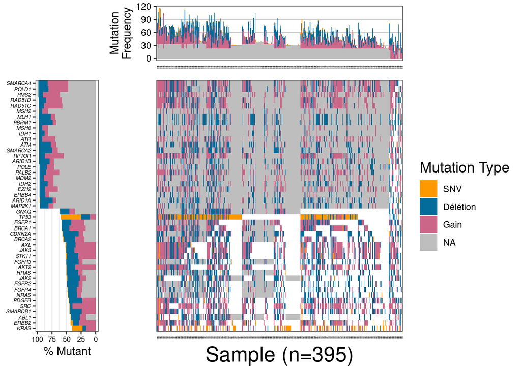

```r
# Je crois que les nombres de patient ne sont pas cherent avec le flowchart car mon script ne note pas les patients qui n'ont aucune muattion ! A améliorer !

CNV_SNV_all_patients <-
  rbind(CNV_all_patients, SNV_all_patients) %>%
  mutate(type_mutation = ifelse(is.na(type_mutation), "NA", type_mutation)) %>%
  select(num_inclusion, gene, type_mutation) %>%
  setnames(c("sample", "gene", "mutation")) %>%
  filter(mutation != "Pas de mutation")

myHierarchy8 <- data.table("mutation"=c("SNV", "Délétion", "Gain", "NA"), color=c("#FF9900", "#046C9A", "#CC6688", "grey")) # Permet de représenter en priorité des types de mutation, ici on a que des mutations Missense donc pas très utile


newLayerA <- list(theme(axis.text.x=element_text(angle=90, color="black", size=1)))
newLayerB <- list(theme(axis.text.x=element_text(angle=0, color="black", size=7),
                        axis.text.y=element_text(angle=0, color="black", size=5)))
newLayerC <- list(theme(axis.text.x=element_text(angle=90, color="black", size=1)))

plotData8 <- Waterfall(CNV_SNV_all_patients, mutationHierarchy = myHierarchy8, geneMax=45, plotATally = "complex",plotALayers = newLayerA, plotBTally = "complex", plotBLayers = newLayerB, sampleNames = TRUE, sectionHeights = c(0.2, 0.6, 0.2), sectionWidths = c(0.2, 0.8), plotCLayers = newLayerC)

drawPlot(plotData8)
```

```r
dd4_organ <- dd4 %>% select(num_inclusion, organ)

CNV_all_patients <-
  read.delim(file = "projet_ImmunoProfiler_genomique/projet_ImmunoProfiler_genomique/resultats_CNV_all_patients.txt") %>%
  mutate(num_inclusion = substring(num_inclusion, first = 2)) %>% # Je conserve les char après la position 2 (après le "p")
  left_join(dd4_organ, by = "num_inclusion") %>%
  filter(!is.na(organ))

length(unique(CNV_all_patients$num_inclusion))
```

```
## [1] 335
```

```r
SNV_all_patients <-
  read.delim(file = "projet_ImmunoProfiler_genomique/projet_ImmunoProfiler_genomique/resultats_SNV_all_patients.txt") %>%
  mutate(num_inclusion = substring(num_inclusion, first = 2)) %>% # Je conserve les char après la position 2 (après le "p")
  left_join(dd4_organ, by = "num_inclusion") %>%
  filter(!is.na(organ))

length(unique(SNV_all_patients$num_inclusion))
```

```
## [1] 379
```

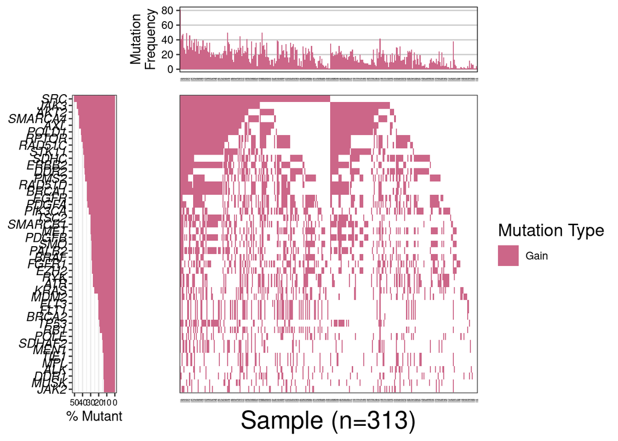

```r
# Je crois que les nombres de patient ne sont pas cherent avec le flowchart car mon script ne note pas les patients qui n'ont aucune muattion ! A améliorer !

CNV_SNV_all_patients <-
  rbind(CNV_all_patients, SNV_all_patients) %>%
  mutate(type_mutation = ifelse(is.na(type_mutation), "NA", type_mutation)) %>%
  select(num_inclusion, gene, type_mutation) %>%
  setnames(c("sample", "gene", "mutation")) %>%
  # filter(mutation != "Pas de mutation", mutation != "NA", mutation != "Gain", mutation != "Délétion") # POur voir les gènes avec le plus de SNV
  # filter(mutation != "Pas de mutation", mutation != "NA", mutation != "Gain", mutation != "SNV") # Pour voir les gènes avec le plus de CNV type Délétion
  filter(mutation != "Pas de mutation", mutation != "NA", mutation != "SNV", mutation != "Délétion") #Pour voir les gènes avec le plus de CNV type Gain


# myHierarchy8 <- data.table("mutation"=c("SNV"), color=c("#FF9900")) # POur voir les gènes avec le plus de SNV
# myHierarchy8 <- data.table("mutation"=c("Délétion"), color=c("#046C9A")) # POur voir les gènes avec le plus de CNV type Délétion
myHierarchy8 <- data.table("mutation"=c("Gain"), color=c("#CC6688")) # POur voir les gènes avec le plus de CNV type Gain


newLayerA <- list(theme(axis.text.x=element_text(angle=90, color="black", size=1)))
newLayerB <- list(theme(axis.text.x=element_text(angle=0, color="black", size=7),
                        axis.text.y=element_text(angle=0, color="black", size=10)))
newLayerC <- list(theme(axis.text.x=element_text(angle=90, color="black", size=1)))

plotData8 <- Waterfall(CNV_SNV_all_patients, mutationHierarchy = myHierarchy8, geneMax=45, plotATally = "complex",plotALayers = newLayerA, plotBTally = "complex", plotBLayers = newLayerB, sampleNames = TRUE, sectionHeights = c(0.2, 0.6, 0.2), sectionWidths = c(0.2, 0.8), plotCLayers = newLayerC)

drawPlot(plotData8)
```

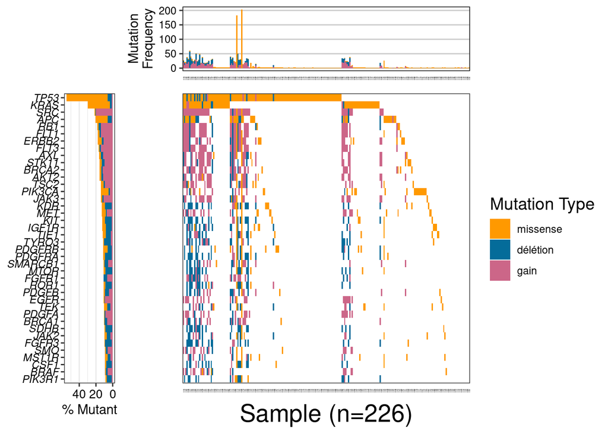

```r
myVars_9bis <- myVars[,1:3]
myVars9 <- d_info_cnv %>% filter(Categorie_cancer == "Carcinome colorectal")
myVars9 <- myVars9[,1:3] %>% setnames(c("sample", "gene", "mutation"))

myVars9 <- rbind(myVars_9bis, myVars9)

myHierarchy9 <- data.table("mutation"=c("missense", "délétion", "gain"), color=c("#FF9900", "#046C9A", "#CC6688")) # Permet de représenter en priorité des types de mutation, ici on a que des mutations Missense donc pas très utile

newLayerA <- list(theme(axis.text.x=element_text(angle=90, color="black", size=1)))
newLayerB <- list(theme(axis.text.x=element_text(angle=0, color="black", size=10)))
newLayerC <- list(theme(axis.text.x=element_text(angle=90, color="black", size=1)))

plotData9 <- Waterfall(myVars9, mutationHierarchy = myHierarchy9, geneMax=40, plotATally = "complex",plotALayers = newLayerA, plotBTally = "complex", plotBLayers = newLayerB, sampleNames = TRUE, sectionHeights = c(0.2, 0.6, 0.2), sectionWidths = c(0.2, 0.8), plotCLayers = newLayerC)

drawPlot(plotData9)
```

```r
myVars_SNV_allcancer <-
  d_info_mutation %>%
  filter(organ == "Digestif") %>%
  mutate(trv_type = "SNV") %>%
  select(c("num_inclusion", "gene_symbol", "trv_type")) %>%
  setnames(c("sample", "gene", "mutation"))

myVars_CNV_allcancer <-
  d_info_cnv %>%
  filter(organ == "Digestif") %>%
  select(c("num_inclusion", "gene", "type_mutation")) %>%
  setnames(c("sample", "gene", "mutation"))

myVars_SNV_CNV_allcancer <- rbind(myVars_SNV_allcancer, myVars_CNV_allcancer)

myHierarchy8 <- data.table("mutation"=c("SNV", "délétion", "gain"), color=c("#FF9900", "#046C9A", "#CC6688")) # Permet de représenter en priorité des types de mutation, ici on a que des mutations Missense donc pas très utile


newLayerA <- list(theme(axis.text.x=element_text(angle=90, color="black", size=1)))
newLayerB <- list(theme(axis.text.x=element_text(angle=0, color="black", size=10)))
newLayerC <- list(theme(axis.text.x=element_text(angle=90, color="black", size=1)))

plotData8 <- Waterfall(myVars_SNV_CNV_allcancer, mutationHierarchy = myHierarchy8, geneMax=60, plotATally = "complex",plotALayers = newLayerA, plotBTally = "complex", plotBLayers = newLayerB, sampleNames = TRUE, sectionHeights = c(0.2, 0.6, 0.2), sectionWidths = c(0.2, 0.8), plotCLayers = newLayerC)

drawPlot(plotData8)
```

[output not shown]

```r
dd4_organ <- dd4 %>% select(num_inclusion, organ)

CNV_all_patients <-
  read.delim(file = "projet_ImmunoProfiler_genomique/projet_ImmunoProfiler_genomique/resultats_CNV_all_patients.txt") %>%
  mutate(num_inclusion = substring(num_inclusion, first = 2)) %>% # Je conserve les char après la position 2 (après le "p")
  left_join(dd4_organ, by = "num_inclusion") %>%
  filter(!is.na(organ))

length(unique(CNV_all_patients$num_inclusion))
```

```
## [1] 335
```

```r
SNV_all_patients <-
  read.delim(file = "projet_ImmunoProfiler_genomique/projet_ImmunoProfiler_genomique/resultats_SNV_all_patients.txt") %>%
  mutate(num_inclusion = substring(num_inclusion, first = 2)) %>% # Je conserve les char après la position 2 (après le "p")
  left_join(dd4_organ, by = "num_inclusion") %>%
  filter(!is.na(organ))

length(unique(SNV_all_patients$num_inclusion))
```

```
## [1] 379
```

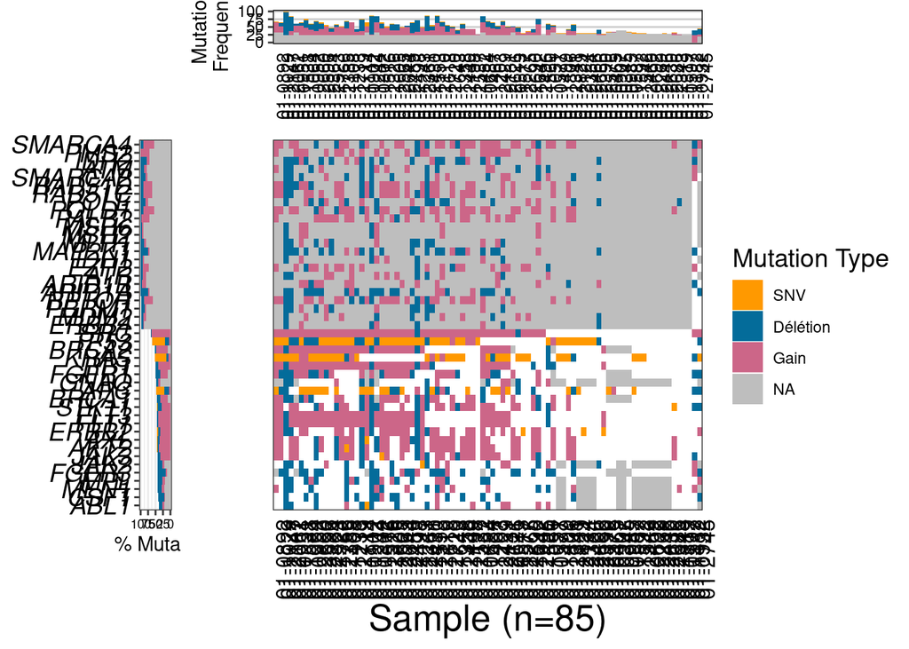

```r
# Je crois que les nombres de patient ne sont pas cherent avec le flowchart car mon script ne note pas les patients qui n'ont aucune muattion ! A améliorer !

CNV_SNV_colorectal_patients <-
  rbind(CNV_all_patients, SNV_all_patients) %>%
  mutate(type_mutation = ifelse(is.na(type_mutation), "NA", type_mutation)) %>%
  filter(organ == "Digestif") %>%
  select(num_inclusion, gene, type_mutation) %>%
  setnames(c("sample", "gene", "mutation")) %>%
  filter(mutation != "Pas de mutation")

myHierarchy8 <- data.table("mutation"=c("SNV", "Délétion", "Gain", "NA"), color=c("#FF9900", "#046C9A", "#CC6688", "grey")) # Permet de représenter en priorité des types de mutation, ici on a que des mutations Missense donc pas très utile


newLayerA <- list(theme(axis.text.x=element_text(angle=90, color="black", size=10)))
newLayerB <- list(theme(axis.text.x=element_text(angle=0, color="black", size=7),
                        axis.text.y=element_text(angle=0, color="black", size=14)))
newLayerC <- list(theme(axis.text.x=element_text(angle=90, color="black", size=12)))


plotData8 <- Waterfall(CNV_SNV_colorectal_patients, mutationHierarchy = myHierarchy8, geneMax=45, plotATally = "complex",plotALayers = newLayerA, plotBTally = "complex", plotBLayers = newLayerB, sampleNames = TRUE, sectionHeights = c(0.2, 0.6, 0.2), sectionWidths = c(0.2, 0.8), plotCLayers = newLayerC)

drawPlot(plotData8)
```

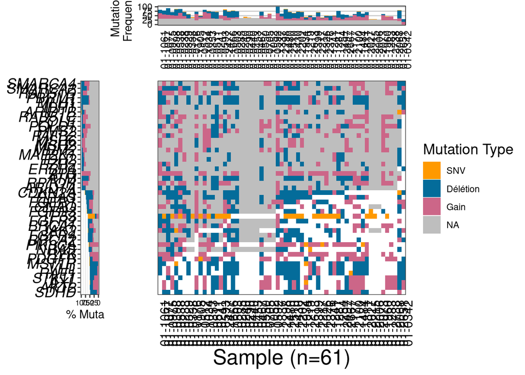

```r
CNV_SNV_colorectal_patients <-
  rbind(CNV_all_patients, SNV_all_patients) %>%
  mutate(type_mutation = ifelse(is.na(type_mutation), "NA", type_mutation)) %>%
  filter(organ == "ORL") %>%
  select(num_inclusion, gene, type_mutation) %>%
  setnames(c("sample", "gene", "mutation")) %>%
  filter(mutation != "Pas de mutation")

myHierarchy8 <- data.table("mutation"=c("SNV", "Délétion", "Gain", "NA"), color=c("#FF9900", "#046C9A", "#CC6688", "grey")) # Permet de représenter en priorité des types de mutation, ici on a que des mutations Missense donc pas très utile


newLayerA <- list(theme(axis.text.x=element_text(angle=90, color="black", size=10)))
newLayerB <- list(theme(axis.text.x=element_text(angle=0, color="black", size=7),
                        axis.text.y=element_text(angle=0, color="black", size=14)))
newLayerC <- list(theme(axis.text.x=element_text(angle=90, color="black", size=12)))

plotData8 <- Waterfall(CNV_SNV_colorectal_patients, mutationHierarchy = myHierarchy8, geneMax=45, plotATally = "complex",plotALayers = newLayerA, plotBTally = "complex", plotBLayers = newLayerB, sampleNames = TRUE, sectionHeights = c(0.2, 0.6, 0.2), sectionWidths = c(0.2, 0.8), plotCLayers = newLayerC)

drawPlot(plotData8)
```

```r
dd4_organ <- dd4 %>% select(num_inclusion, organ)

CNV_all_patients <-
  read.delim(file = "projet_ImmunoProfiler_genomique/projet_ImmunoProfiler_genomique/resultats_CNV_all_patients.txt") %>%
  mutate(num_inclusion = substring(num_inclusion, first = 2)) %>% # Je conserve les char après la position 2 (après le "p")
  left_join(dd4_organ, by = "num_inclusion") %>%
  filter(!is.na(organ))

length(unique(CNV_all_patients$num_inclusion))
```

```
## [1] 335
```

```r
SNV_all_patients <-
  read.delim(file = "projet_ImmunoProfiler_genomique/projet_ImmunoProfiler_genomique/resultats_SNV_all_patients.txt") %>%
  mutate(num_inclusion = substring(num_inclusion, first = 2)) %>% # Je conserve les char après la position 2 (après le "p")
  left_join(dd4_organ, by = "num_inclusion") %>%
  filter(!is.na(organ))

length(unique(SNV_all_patients$num_inclusion))
```

```
## [1] 379
```

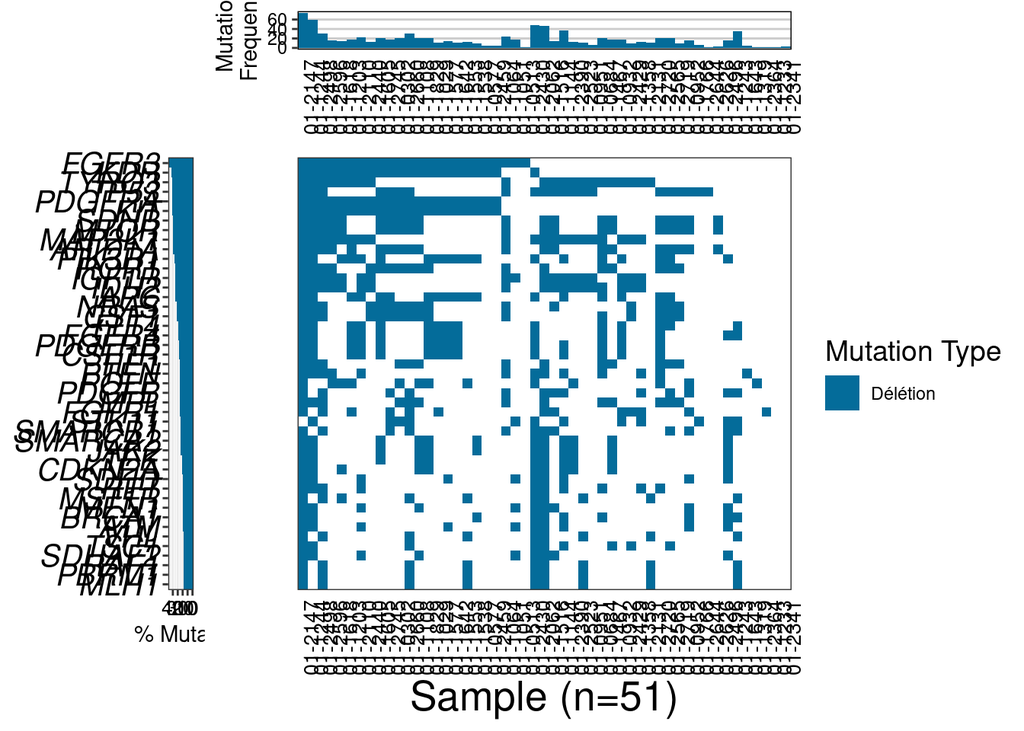

```r
CNV_SNV_colorectal_patients <-
  rbind(CNV_all_patients, SNV_all_patients) %>%
  mutate(type_mutation = ifelse(is.na(type_mutation), "NA", type_mutation)) %>%
  filter(organ == "Digestif") %>%
  select(num_inclusion, gene, type_mutation) %>%
  setnames(c("sample", "gene", "mutation")) %>%
  filter(mutation != "Pas de mutation") %>%
  # filter(mutation != "Pas de mutation", mutation != "NA", mutation != "Gain", mutation != "Délétion") # POur voir les gènes avec le plus de SNV
  filter(mutation != "Pas de mutation", mutation != "NA", mutation != "Gain", mutation != "SNV") # Pour voir les gènes avec le plus de CNV type Délétion
  # filter(mutation != "Pas de mutation", mutation != "NA", mutation != "SNV", mutation != "Délétion") #Pour voir les gènes avec le plus de CNV type Gain


# myHierarchy8 <- data.table("mutation"=c("SNV"), color=c("#FF9900")) # POur voir les gènes avec le plus de SNV
myHierarchy8 <- data.table("mutation"=c("Délétion"), color=c("#046C9A")) # POur voir les gènes avec le plus de CNV type Délétion
# myHierarchy8 <- data.table("mutation"=c("Gain"), color=c("#CC6688")) # POur voir les gènes avec le plus de CNV type Gain


newLayerA <- list(theme(axis.text.x=element_text(angle=90, color="black", size=10)))
newLayerB <- list(theme(axis.text.x=element_text(angle=0, color="black", size=10),
                        axis.text.y=element_text(angle=0, color="black", size=15)))
newLayerC <- list(theme(axis.text.x=element_text(angle=90, color="black", size=10)))

plotData8 <- Waterfall(CNV_SNV_colorectal_patients, mutationHierarchy = myHierarchy8, geneMax=45, plotATally = "complex",plotALayers = newLayerA, plotBTally = "complex", plotBLayers = newLayerB, sampleNames = TRUE, sectionHeights = c(0.2, 0.6, 0.2), sectionWidths = c(0.2, 0.8), plotCLayers = newLayerC)

drawPlot(plotData8)
```

### Waterfall Plot CSV et mutations (ORL cancers)

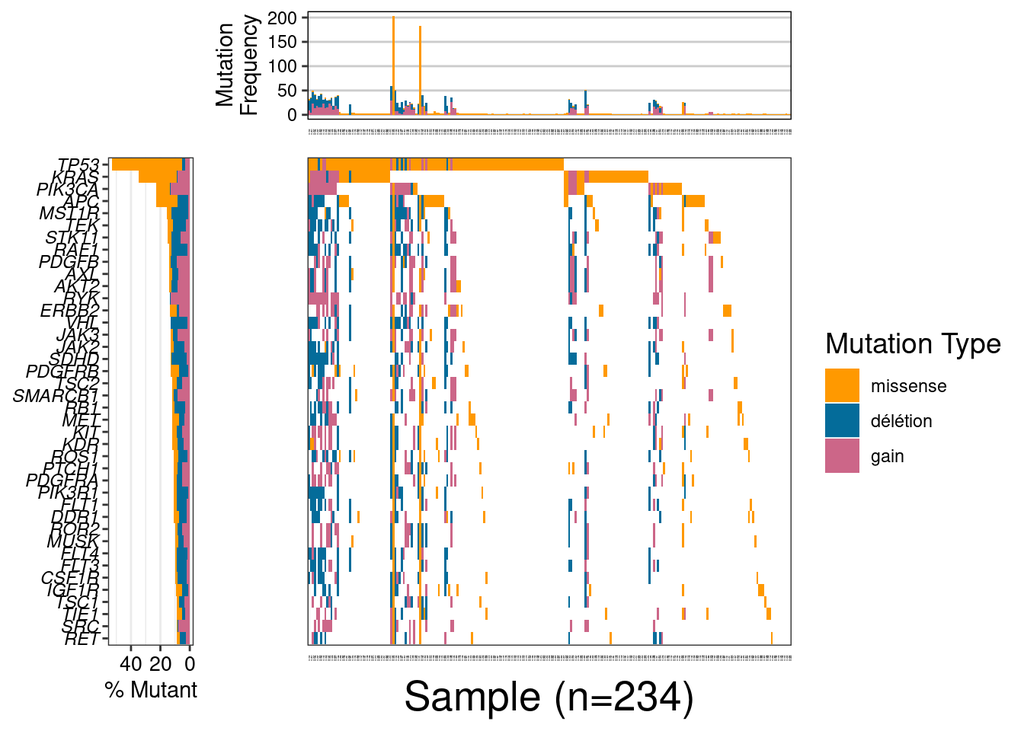

```r
myVars_10bis <- myVars[,1:3]
myVars10 <- d_info_cnv %>% filter(Categorie_cancer == "ORL")
myVars10 <- myVars10[,1:3] %>% setnames(c("sample", "gene", "mutation"))

myVars10 <- rbind(myVars_10bis, myVars10)

myHierarchy10 <- data.table("mutation"=c("missense", "délétion", "gain"), color=c("#FF9900", "#046C9A", "#CC6688")) # Permet de représenter en priorité des types de mutation, ici on a que des mutations Missense donc pas très utile


newLayerA <- list(theme(axis.text.x=element_text(angle=90, color="black", size=1)))
newLayerB <- list(theme(axis.text.x=element_text(angle=0, color="black", size=10)))
newLayerC <- list(theme(axis.text.x=element_text(angle=90, color="black", size=1)))

plotData10 <- Waterfall(myVars10, mutationHierarchy = myHierarchy10, geneMax=40, plotATally = "complex",plotALayers = newLayerA, plotBTally = "complex", plotBLayers = newLayerB, sampleNames = TRUE, sectionHeights = c(0.2, 0.6, 0.2), sectionWidths = c(0.2, 0.8), plotCLayers = newLayerC)

drawPlot(plotData10)
```

```r
dd4_organ <- dd4 %>% select(num_inclusion, organ)

CNV_all_patients <-
  read.delim(file = "projet_ImmunoProfiler_genomique/projet_ImmunoProfiler_genomique/resultats_CNV_all_patients.txt") %>%
  mutate(num_inclusion = substring(num_inclusion, first = 2)) %>% # Je conserve les char après la position 2 (après le "p")
  left_join(dd4_organ, by = "num_inclusion") %>%
  filter(!is.na(organ))

length(unique(CNV_all_patients$num_inclusion))
```

```
## [1] 335
```

```r
SNV_all_patients <-
  read.delim(file = "projet_ImmunoProfiler_genomique/projet_ImmunoProfiler_genomique/resultats_SNV_all_patients.txt") %>%
  mutate(num_inclusion = substring(num_inclusion, first = 2)) %>% # Je conserve les char après la position 2 (après le "p")
  left_join(dd4_organ, by = "num_inclusion") %>%
  filter(!is.na(organ))

length(unique(SNV_all_patients$num_inclusion))
```

```
## [1] 379
```

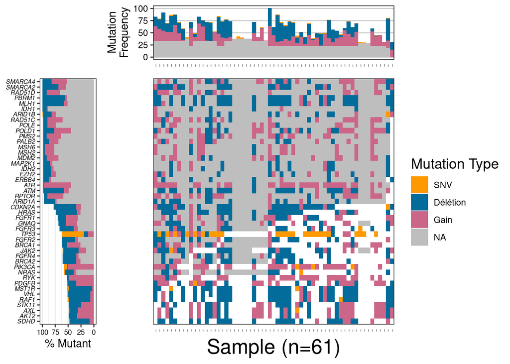

```r
# Je crois que les nombres de patient ne sont pas cherent avec le flowchart car mon script ne note pas les patients qui n'ont aucune muattion ! A améliorer !

CNV_SNV_orl_patients <-
  rbind(CNV_all_patients, SNV_all_patients) %>%
  mutate(type_mutation = ifelse(is.na(type_mutation), "NA", type_mutation)) %>%
  filter(organ == "ORL") %>%
  select(num_inclusion, gene, type_mutation) %>%
  setnames(c("sample", "gene", "mutation")) %>%
  filter(mutation != "Pas de mutation")

myHierarchy8 <- data.table("mutation"=c("SNV", "Délétion", "Gain", "NA"), color=c("#FF9900", "#046C9A", "#CC6688", "grey")) # Permet de représenter en priorité des types de mutation, ici on a que des mutations Missense donc pas très utile


newLayerA <- list(theme(axis.text.x=element_text(angle=90, color="black", size=1)))
newLayerB <- list(theme(axis.text.x=element_text(angle=0, color="black", size=7),
                        axis.text.y=element_text(angle=0, color="black", size=6)))
newLayerC <- list(theme(axis.text.x=element_text(angle=90, color="black", size=1)))

plotData8 <- Waterfall(CNV_SNV_orl_patients, mutationHierarchy = myHierarchy8, geneMax=45, plotATally = "complex",plotALayers = newLayerA, plotBTally = "complex", plotBLayers = newLayerB, sampleNames = TRUE, sectionHeights = c(0.2, 0.6, 0.2), sectionWidths = c(0.2, 0.8), plotCLayers = newLayerC)

drawPlot(plotData8)
```

```r
dd4_organ <- dd4 %>% select(num_inclusion, organ)

CNV_all_patients <-
  read.delim(file = "projet_ImmunoProfiler_genomique/projet_ImmunoProfiler_genomique/resultats_CNV_all_patients.txt") %>%
  mutate(num_inclusion = substring(num_inclusion, first = 2)) %>% # Je conserve les char après la position 2 (après le "p")
  left_join(dd4_organ, by = "num_inclusion") %>%
  filter(!is.na(organ))

length(unique(CNV_all_patients$num_inclusion))
```

```
## [1] 335
```

```r
SNV_all_patients <-
  read.delim(file = "projet_ImmunoProfiler_genomique/projet_ImmunoProfiler_genomique/resultats_SNV_all_patients.txt") %>%
  mutate(num_inclusion = substring(num_inclusion, first = 2)) %>% # Je conserve les char après la position 2 (après le "p")
  left_join(dd4_organ, by = "num_inclusion") %>%
  filter(!is.na(organ))

length(unique(SNV_all_patients$num_inclusion))
```

```
## [1] 379
```

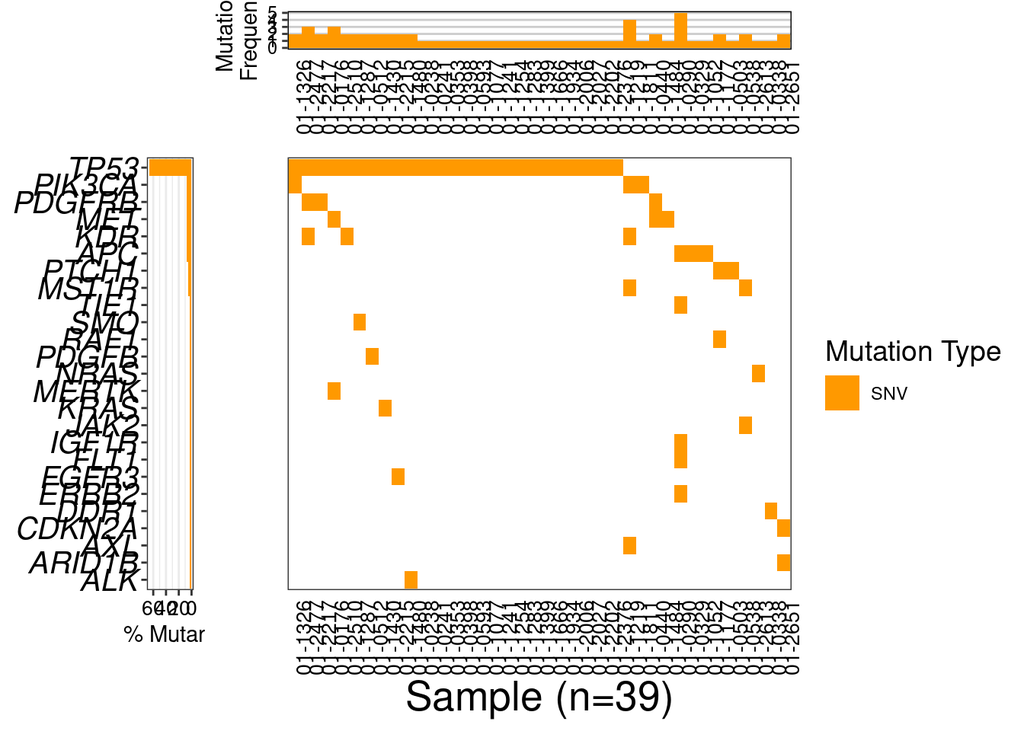

```r
# Je crois que les nombres de patient ne sont pas cherent avec le flowchart car mon script ne note pas les patients qui n'ont aucune muattion ! A améliorer !

CNV_SNV_colorectal_patients <-
  rbind(CNV_all_patients, SNV_all_patients) %>%
  mutate(type_mutation = ifelse(is.na(type_mutation), "NA", type_mutation)) %>%
  filter(organ == "ORL") %>%
  select(num_inclusion, gene, type_mutation) %>%
  setnames(c("sample", "gene", "mutation")) %>%
  filter(mutation != "Pas de mutation") %>%
  filter(mutation != "Pas de mutation", mutation != "NA", mutation != "Gain", mutation != "Délétion") # POur voir les gènes avec le plus de SNV
  # filter(mutation != "Pas de mutation", mutation != "NA", mutation != "Gain", mutation != "SNV") # Pour voir les gènes avec le plus de CNV type Délétion
  # filter(mutation != "Pas de mutation", mutation != "NA", mutation != "SNV", mutation != "Délétion") #Pour voir les gènes avec le plus de CNV type Gain


myHierarchy8 <- data.table("mutation"=c("SNV"), color=c("#FF9900")) # POur voir les gènes avec le plus de SNV
# myHierarchy8 <- data.table("mutation"=c("Délétion"), color=c("#046C9A")) # POur voir les gènes avec le plus de CNV type Délétion
# myHierarchy8 <- data.table("mutation"=c("Gain"), color=c("#CC6688")) # POur voir les gènes avec le plus de CNV type Gain


newLayerA <- list(theme(axis.text.x=element_text(angle=90, color="black", size=10)))
newLayerB <- list(theme(axis.text.x=element_text(angle=0, color="black", size=10),
                        axis.text.y=element_text(angle=0, color="black", size=15)))
newLayerC <- list(theme(axis.text.x=element_text(angle=90, color="black", size=10)))

plotData8 <- Waterfall(CNV_SNV_colorectal_patients, mutationHierarchy = myHierarchy8, geneMax=45, plotATally = "complex",plotALayers = newLayerA, plotBTally = "complex", plotBLayers = newLayerB, sampleNames = TRUE, sectionHeights = c(0.2, 0.6, 0.2), sectionWidths = c(0.2, 0.8), plotCLayers = newLayerC)

drawPlot(plotData8)
```

# Multi-Omics Analysis Factor (MOFA)

```r
# Load le moèle MOFA déja entrainer
MOFAobject.trained <- load_model("model_MOFA_trained.hdf5")

# Ou pour réentrainer le modèle MOFA :
######################################
#
# long_df_immuno <-
#   dd4 %>% # On prend toutes nos données
#   select(num_inclusion, all_of(names(dd4)[7:37])) %>%  # On ne garde que la colonne "num_inclusion" et les colonnes immuno_pop_totales (col 7 à 37)
#   tidyr::pivot_longer(cols = !num_inclusion, names_to = "feature", values_to = "value") %>% # Fait format long du dataframe en répétant les features pour chaque num_inclusion
#   mutate(view = "I") %>% # On rajoute une colonne "view" qui prend la valeur "I" pour toutes les lignes (I = Immuno)
#   left_join(dd4 %>% select(num_inclusion, organ), by = "num_inclusion") %>% # On rajoute la colonne "organ" correspondant au type de cancer pour chaque num_inclusion
#   rename(sample = num_inclusion, group = organ) %>% # On renomme les colonnes de façon à être conforme avec MOFA
#   mutate(value = log10((value * 1000000 + 1) )) # +1 pour enlever les 0 et 10⁶ pour les unité de cytométrie à vérifier
#
# Figure rapport : ################################################################################
# ### Visualisation de l'effet de passer en log pour avoir une belle Gaussienne
# png("combined_image.png", width = 1600, height = 800)
# par(mfrow = c(1, 2))
#
# # Sans le log :
# Sans_Log <- hist(dd5$NK,
#           xlab = "Values",
#           ylab = "Fréquence",
#           main = "Histogramme des valeurs des NK\nsans log transformation")

# # Avec le log :
# Avec_Log <- hist(log10(dd5$NK * 1000000 +1),
#           xlab = "Log(Values)",
#           ylab = "Fréquence",
#           main = "Histogramme des valeurs des NK\navec log transformation")
#
# dev.off()
# ################################################################################
#
#
#
# matrix_missense <-
#   dd4 %>% # On prend toutes nos données
#   select(num_inclusion, all_of(names(dd4)[147:239]))  # On ne garde que la colonne "num_inclusion" et les colonnes de mutation missense (col 147 à 239)
#
# # On enleve les gènes qui ont bien trop de NA
# nbNA_gene <- colSums(is.na(matrix_missense)) # On fait le total des NA pur chaque colonne
# table(nbNA_gene) # Affiche le nombre de NA par colonne (par gène)
# matrix_missense_narm <- matrix_missense[ , nbNA_gene < 273] # On enleve les 23 gènes qui on plus de 319 NA (trop de données manquantes (> 25%))
#
# long_df_missense <-
#   matrix_missense_narm %>% # On prend la matrice de mutation missense nettoyé des gènes avec trop de NA
#   tidyr::pivot_longer(cols = !num_inclusion, names_to = "feature", values_to = "value") %>% # Fait format long du dataframe en répétant les features pour chaque num_inclusion
#   mutate(view = "G") %>% # On rajoute une colonne "view" qui prend la valeur "G" pour toutes les lignes (G = Génomique)
#   left_join(dd4 %>% select(num_inclusion, organ), by = "num_inclusion") %>% # On rajoute la colonne "organ" correspondant au type de cancer pour chaque num_inclusion
#   rename(sample = num_inclusion, group = organ) # On renomme les colonnes de façon à être conforme avec MOFA
#
#
#
# matrix_cnv <-
#   dd4 %>% # On prend toutes nos données
#   select(num_inclusion, all_of(names(dd4)[240:332]))  # On ne garde que la colonne "num_inclusion" et les colonnes de mutation cnv (col 240 à 332)
#
# # On enleve les gènes qui ont bien trop de NA
# nbNA_gene <- colSums(is.na(matrix_cnv)) # On fait le total des NA pur chaque colonne
# table(nbNA_gene) # Affiche le nombre de NA par colonne (par gène)
# # On a pas de gène qui à beaucoup de NA par contre il y a des certains individus qui n'ont pas de données, on va donc les enlever
#
# nbNA_ind <- apply(matrix_cnv, 1, FUN = function(x) sum(is.na(x))) # On compte le nombre de valeur manquante NA (on regarde la somme) pour chaque ligne (patients) et on stocke ça dans un vecteur
# table(nbNA_ind) # On regarde ce vecteur (Il y a 167 patients avec des lignes contenant des 93 NA sur les 94 variables !!! On va les enlever)
# matrix_cnv_narm <- matrix_cnv[nbNA_ind < 93,] # On sélectionne que les ligne du vecteur (les patients) qui ont une somme de NA inférieu à 93 NA
#
#
# long_df_cnv <-
#   matrix_cnv_narm %>% # On prend la matrice de mutation cnv nettoyé des individus avec trop de NA
#   tidyr::pivot_longer(cols = !num_inclusion, names_to = "feature", values_to = "value") %>% # Fait le format long du dataframe en répétant les features pour chaque num_inclusion
#   mutate(view = "G") %>% # On rajoute une colonne "view" qui prend la valeur "G" pour toutes les lignes (G = Génomique)
#   left_join(dd4 %>% select(num_inclusion, organ), by = "num_inclusion") %>% # On rajoute la colonne "organ" correspondant au type de cancer pour chaque num_inclusion
#   rename(sample = num_inclusion, group = organ) %>% # On renomme les colonnes de façon à être conforme avec MOFA
#   mutate(value = replace(value, value == -1, 1)) # On remplace les -1 en 1 pour avoir quelque chose binaire mais on perd l'information -1 = délétion et 1 = amplification
#
#
#
#
#
#
#
#
#
# # On est obligé de clean les noms sinon MOFA pas content
# clean_names <- function(names) {
#   names <- gsub("é", "e", names)
#   names <- gsub("è", "e", names)
#   names <- gsub("_", "", names)
#   names <- gsub("\\+", "Plus", names)
#   names <- gsub("-", "Minus", names)
#   names <- gsub(" ", "", names)
#   names <- iconv(names, to="ASCII//TRANSLIT")
#   return(names)
# }
#
# # unique(long_df_combined$feature) # Vérifier que les noms ont été changés
#
#
#
# long_df_combined <-
#   rbind(long_df_immuno, long_df_missense, long_df_cnv) %>% # On combine les 3 longs data_frame
#   filter(!is.na(group)) # On filtre les "organ" (group) pour lequels on des NA (9 ptients) sinon cela pose problème
#
#
# long_df_combined$feature <- clean_names(long_df_combined$feature) # Applique la fonction de nettoyage aux noms de features + autres colonnes
# str(long_df_combined) # On vérifie le long data frame combiné
#
# groups <- long_df_combined$group # On stocke les groupe dans un vecteur
#
#
#
# MOFAobject <- create_mofa(long_df_combined, groups = groups) # On crée l'objet MOFA
# print(MOFAobject) # On a un récap de l'objet
#
# plot_data_overview(MOFAobject) # On regarde les différentes views de l'objet
#
#
# data_opts <- get_default_data_options(MOFAobject)
# data_opts$scale_views <- TRUE # On scale les views
# data_opts$scale_groups <- TRUE # On scale les groupes
# head(data_opts)
#
#
# model_opts <- get_default_model_options(MOFAobject)
# model_opts$likelihoods$G <- "bernoulli" # On a des données binaires donc Bernouilli
# model_opts$likelihoods$I <- "gaussian" # ON a des données continues donc Gauss
# head(model_opts)
#
#
# train_opts <- get_default_training_options(MOFAobject)
# head(train_opts)
#
# # On prepare l'objet MOFA
# MOFAobject <- prepare_mofa(object = MOFAobject,
#                            data_options = data_opts,
#                            model_options = model_opts,
#                            training_options = train_opts)
#
# outfile = file.path(getwd(),"model_MOFA_trained.hdf5")
#
#
# # On entraine le modèle
# MOFAobject.trained <- run_mofa(MOFAobject, outfile, use_basilisk = TRUE)
######################################################









plot_data_overview(MOFAobject.trained) # On regarde les différentes views de l'objet
```

[output not shown]

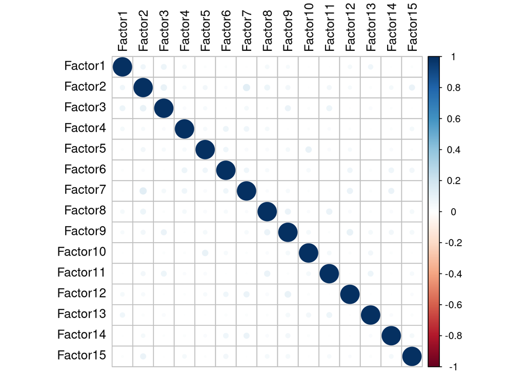

```r
# On ajoute des metadata (age, sexe)
metadata <-
  dd4 %>%
  select(sample = num_inclusion, organ, sexe, age) %>%
  filter(!is.na(organ)) %>%
  rename(group = organ)


samples_metadata(MOFAobject.trained) <- metadata # On donne ces metadata à l'objet MOFA

plot_factor_cor(MOFAobject.trained) # On regarde la corrélation entre les différents facteurs
```

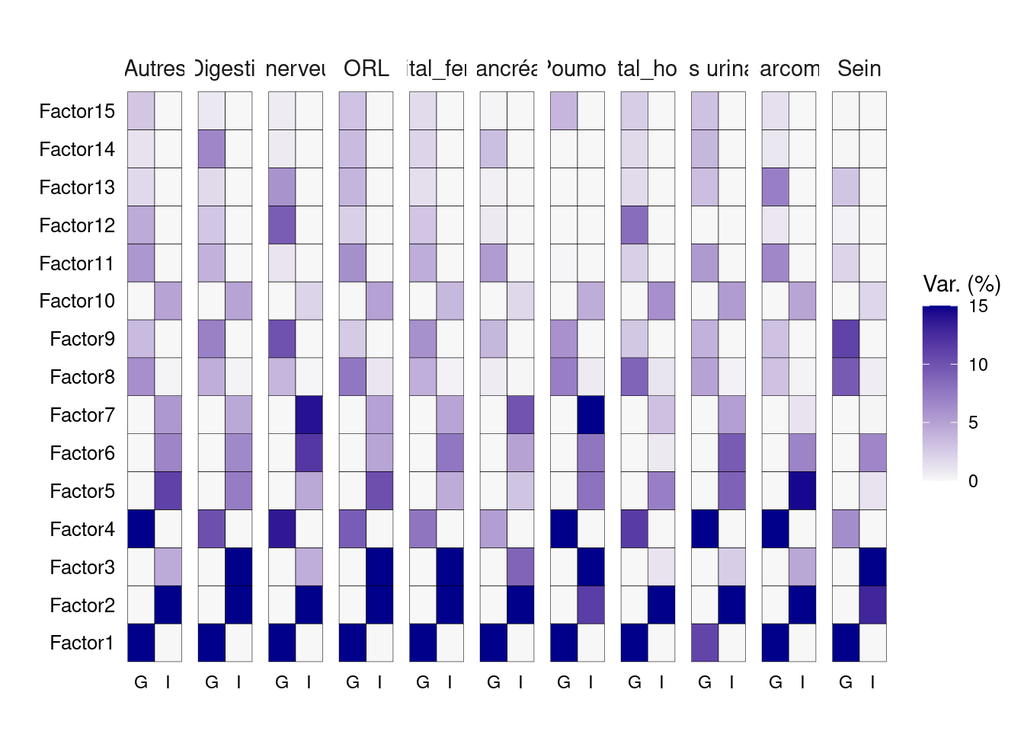

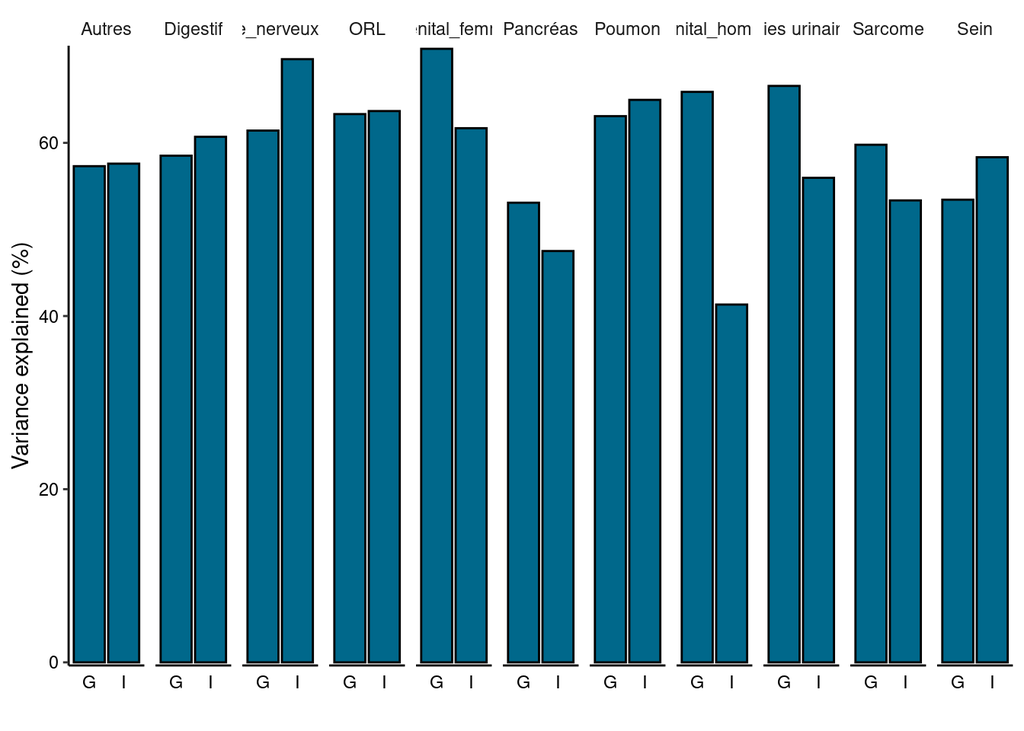

```r
VarEx <- plot_variance_explained(MOFAobject.trained,
                        x = "view",
                        y = "factor",
                        split_by = "group",
                        plot_total = TRUE,
                        factors = "all",
                        min_r2 = 0,
                        max_r2 = 15,
                        legend = TRUE,
                        use_cache = TRUE)
#VarEx <- VarEx + coord_flip()
VarEx
```

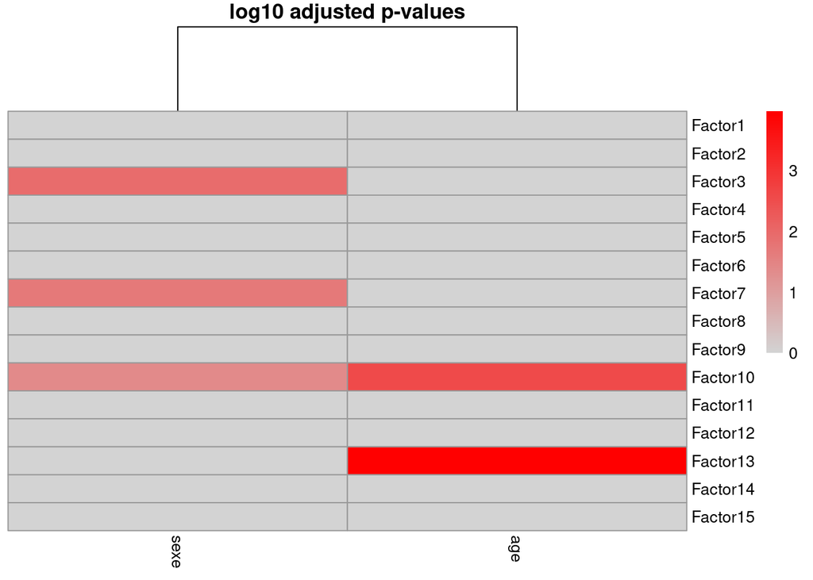

```r
correlate_factors_with_covariates(MOFAobject.trained,
                                  covariates = c("sexe","age"),
                                  plot="log_pval")
```

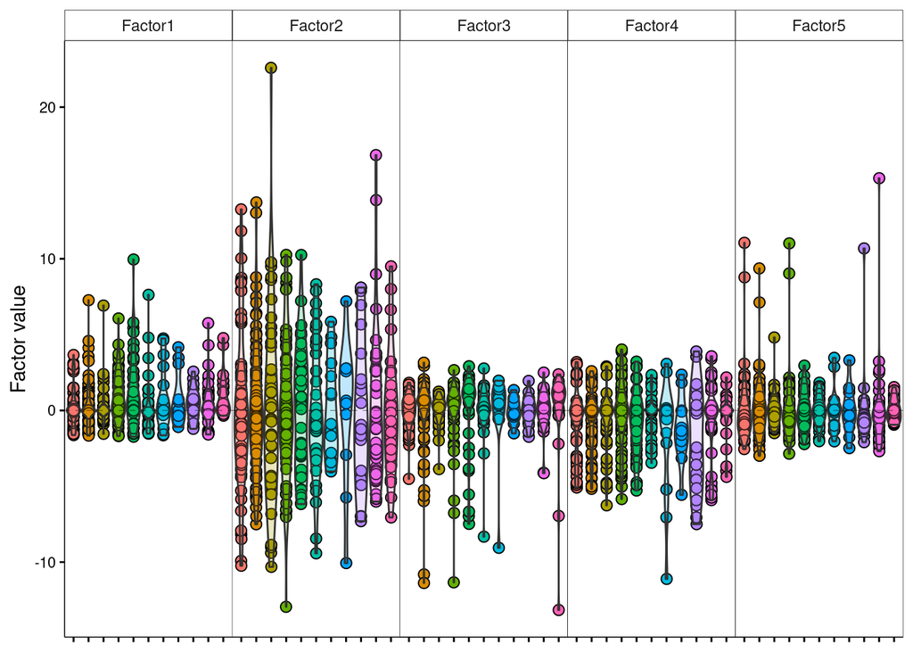

```r
# On regarde les différent type de facteur

# plot_factor(MOFAobject.trained,
#   factors = c(1:5),
#   color_by = "age",
#   shape_by = "sexe",
# )

library(gridExtra)

# Visualisation des facteurs 1 à 5
facteur_1_5 <- plot_factor(MOFAobject.trained,
            factors = c(1:5),
            groups = "all",
            color_by = "group",
            dot_size = 2.5,        # change dot size
            dodge = T,           # dodge points with different colors
            legend = F,          # remove legend
            add_violin = T,      # add violin plots,
            violin_alpha = 0.25) # transparency of violin plots

facteur_1_5 <-
  facteur_1_5 +
  theme(axis.text.x=element_blank())
facteur_1_5
```

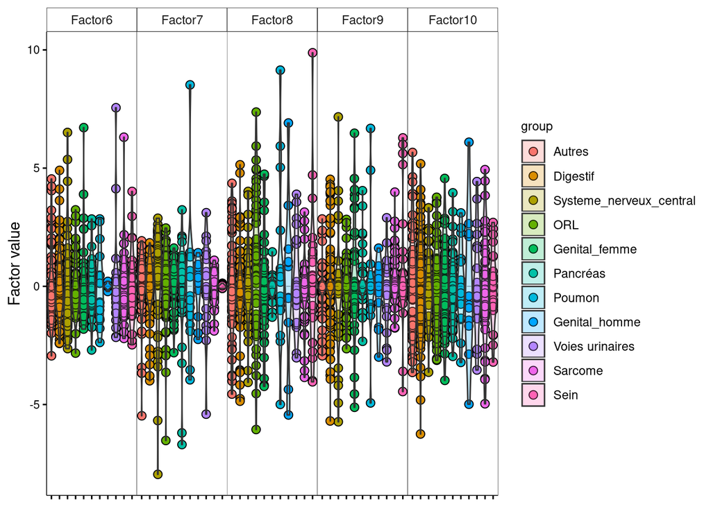

```r
# ggsave(filename = "facteur_1_5.png", plot = facteur_1_5, width = 10, height = 8, dpi = 300)

# Visualisation des facteurs 5 à 10
facteur_6_10 <- plot_factor(MOFAobject.trained,
            factors = c(6:10),
            groups = "all",
            color_by = "group",
            dot_size = 2.5,        # change dot size
            dodge = T,           # dodge points with different colors
            legend = T,          # remove legend
            add_violin = T,      # add violin plots,
            violin_alpha = 0.25)  # transparency of violin plots

facteur_6_10 <-
  facteur_6_10 +
  theme(axis.text.x=element_blank())
facteur_6_10
```

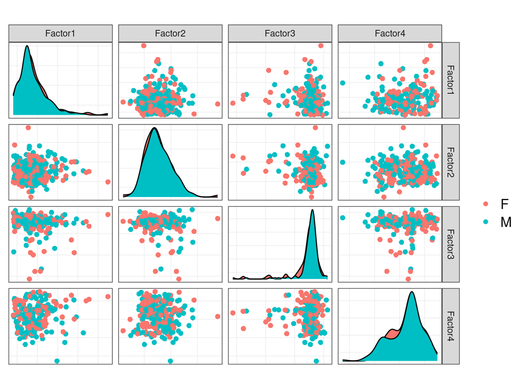

```r
# ggsave(filename = "facteur_6_10_bis.png", plot = facteur_6_10, width = 10, height = 8, dpi = 300)

# Organiser les graphiques en une grille
#grid.arrange(facteur_1_5, facteur_5_10, nrow = 2, ncol = 2)

# Visualisation scatter plot avec plot_factors AVEC UN S !!!
plot_factors(MOFAobject.trained,
             factors = c(1:4),
             show_missing = FALSE,
             color_by = "sexe",
             dot_size = 2,        # change dot size
             legend = T)          # remove legend
```

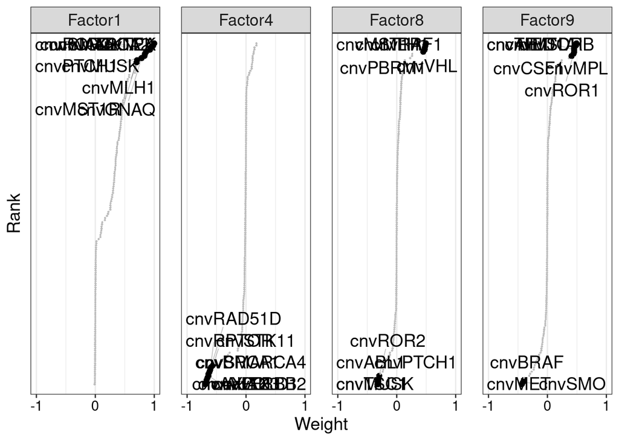

```r
################################################### Caractérisation du facteur 1

# ON regarde les poids de chaque feature dans les facteurs qui expliques le plus la variance dans les view génomique et immuno
plot_weights(MOFAobject.trained,
             view = "G",
             factor = c(1,4,8,9),
             nfeatures = 10,     # Top number of features to highlight
             scale = T)           # Scale weights from -1 to 1
```

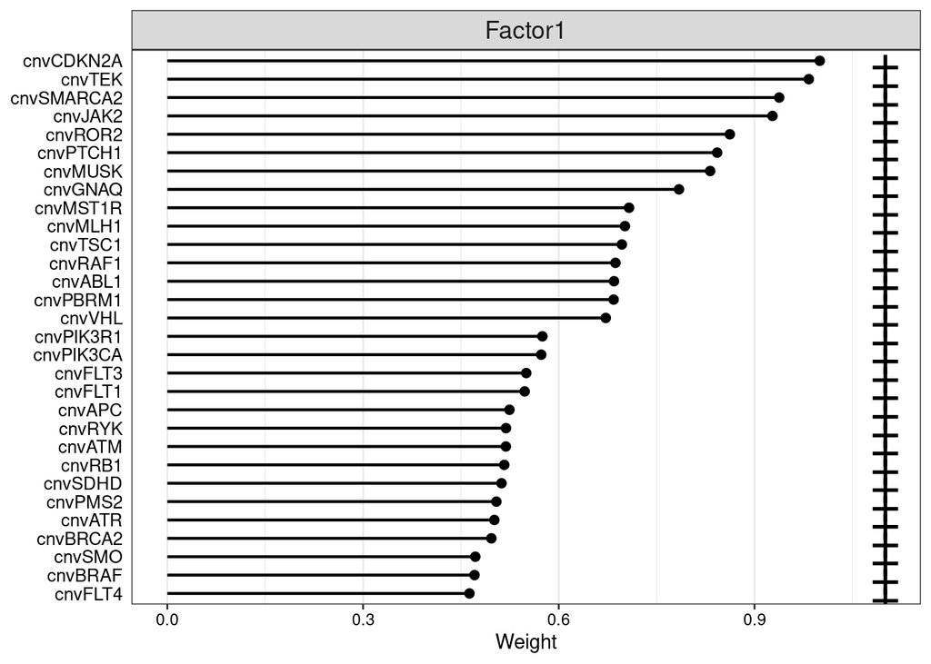

```r
P1 <- plot_top_weights(MOFAobject.trained,
                 view = "G",
                 factor = c(1),
                 nfeatures = 30,     # Top number of features to highlight
                 abs = FALSE,
                 scale = T,
                 sign = "all")           # Scale weights from -1 to 1
P1
```

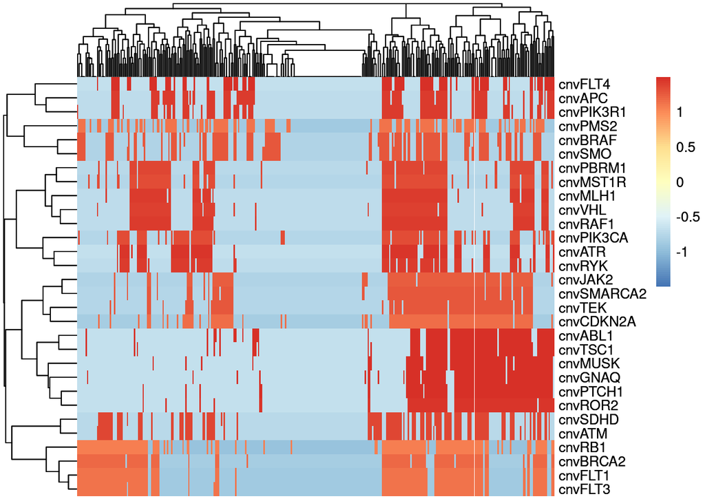

```r
ggsave(filename = "P1.png", plot = P1, width = 10, height = 8, dpi = 300)


# On fait des heatmeaps
P1_bis <- plot_data_heatmap(MOFAobject.trained,
                  view = "G",         # view of interest
                  factor = 1,             # factor of interest
                  features = 30,          # number of features to plot (they are selected by weight)
                  groups = "all",
                  scale = "row",
                  cluster_rows = TRUE,
                  cluster_cols = TRUE,
                  show_rownames = TRUE,
                  show_colnames = FALSE)
P1_bis
```

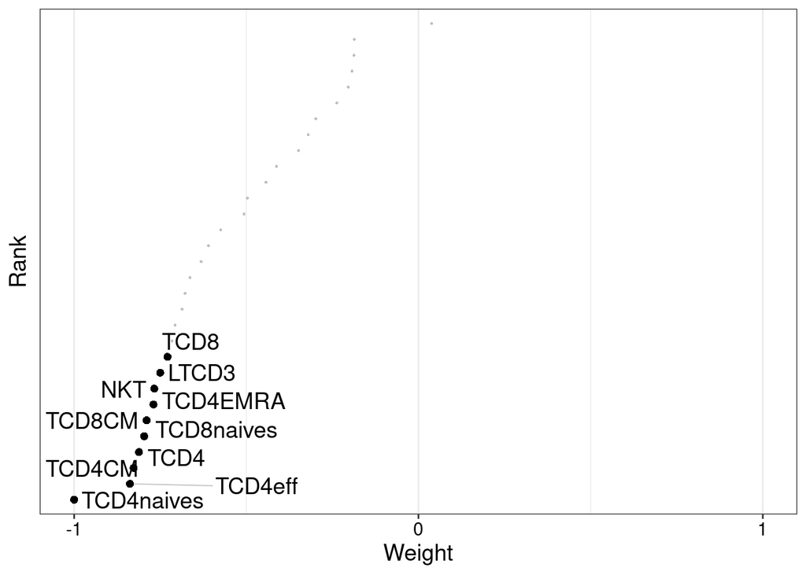

```r
ggsave(filename = "P1_bis.png", plot = P1_bis, width = 10, height = 8, dpi = 300)

################################################### Caractérisation du facteur 2

plot_weights(MOFAobject.trained,
             view = "I",
             factor = c(2),
             nfeatures = 10,     # Top number of features to highlight
             scale = T)
```

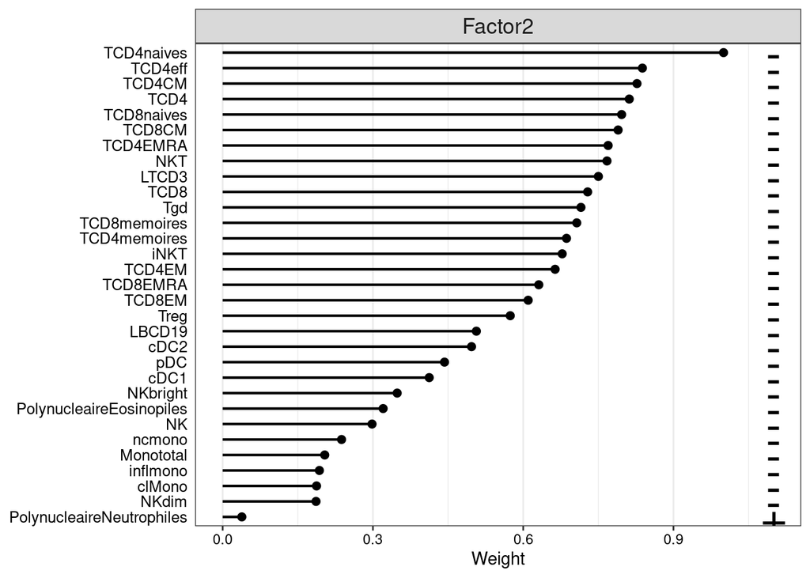

```r
P2 <- plot_top_weights(MOFAobject.trained,
                 view = "I",
                 factor = c(2),
                 nfeatures = "all",     # Top number of features to highlight
                 abs = FALSE,
                 scale = T,
                 sign = "all")           # Scale weights from -1 to 1
P2
```

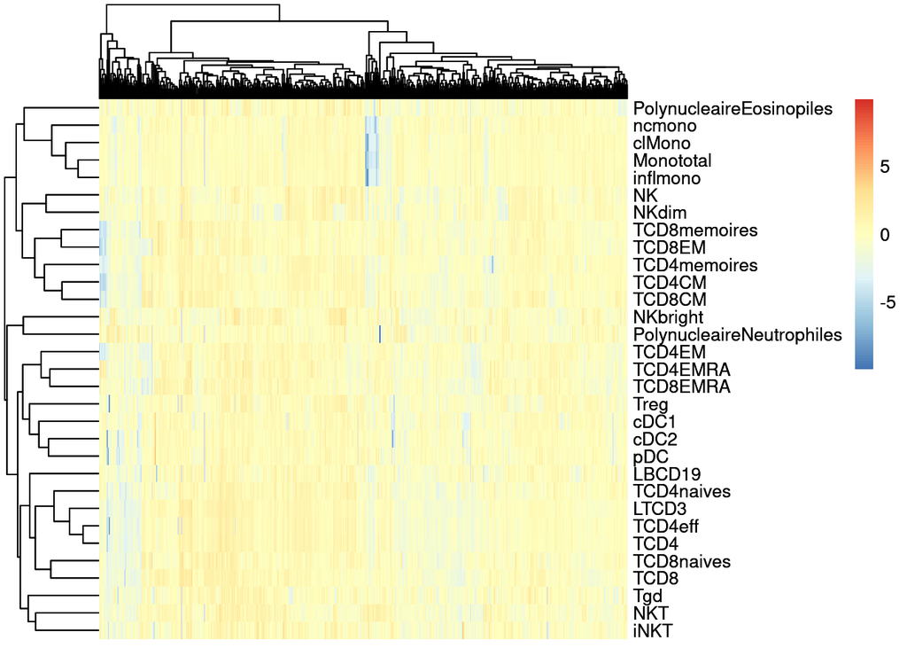

```r
# ggsave(filename = "P2.png", plot = P2, width = 10, height = 8, dpi = 300)


P2_bis <- plot_data_heatmap(MOFAobject.trained,
                  view = "I",
                  factor = 2,
                  features = 31,
                  groups = "all",
                  cluster_rows = TRUE,
                  cluster_cols = TRUE,
                  show_rownames = TRUE,
                  show_colnames = FALSE,
                  scale = "row")
P2_bis
```